# Phan tich right hand

Minh

2024-02-29

## Load bộ số liệu và các packages

## So sánh khác biệt về trung bình của chỉ số M_right theo các biến

Tạo hàm tính 95%CI

Tạo hàm so sánh trung bình bằng Wilcox.test nếu subgroup có 2 level

Tạo hàm so sánh bắt cặp các trung bình bằng Wilcox.pairwise test nếu group có >2 level

Tạo hàm vẽ Forest plot

Hàm để tạo bảng

Sub group list = “Gender”, “Smoking”, “Obesity”, “BMI25”, “Stress index”, “Typer of skins”, “Hypertension”, “Age_stage”

## Tạo bảng và Forest plot với biến M_right

| Subgroup_Category | Subgroup | n_M_right | Mean | CI_lower | CI_upper | P_Value |
| --- | --- | --- | --- | --- | --- | --- |
| Gender | 0 | 31 | 21.24866 | 17.918146 | 24.57917 | 0.4006173 |
| Gender | 1 | 44 | 22.86338 | 19.911520 | 25.81524 | 0.4006173 |
| Smoking | Do not smoke | 62 | 22.67448 | 20.402104 | 24.94686 | 0.4796795 |
| Smoking | Cigarettes, pipe tobacco… | 13 | 19.91377 | 12.918098 | 26.90944 | 0.4796795 |
| Obesity | 0 | 68 | 21.60820 | 19.272501 | 23.94389 | 0.1069954 |
| Obesity | 1 | 7 | 27.90567 | 24.447443 | 31.36389 | 0.1069954 |
| BMI25 | 0 | 42 | 18.83752 | 15.821631 | 21.85340 | 0.0000984 |
| BMI25 | 1 | 33 | 26.47034 | 23.918497 | 29.02219 | 0.0000984 |
| Stress index | 0 | 57 | 20.80047 | 18.319373 | 23.28157 | 0.0124304 |
| Stress index | 1 | 18 | 26.61500 | 22.410480 | 30.81952 | 0.0124304 |
| Typer of skins | 3 | 40 | 19.38852 | 16.283161 | 22.49387 | NA |
| Typer of skins | 4 | 11 | 26.75303 | 23.147883 | 30.35818 | NA |
| Typer of skins | 1 | 10 | 24.73180 | 20.822265 | 28.64134 | NA |
| Typer of skins | 6 | 4 | 29.91750 | 19.431679 | 40.40332 | NA |
| Typer of skins | 2 | 4 | 30.01750 | 21.210866 | 38.82413 | NA |
| Typer of skins | 5 | 6 | 17.96917 | 3.734395 | 32.20394 | NA |
| Hypertension | 0 | 54 | 23.09776 | 20.608567 | 25.58695 | 0.2597899 |
| Hypertension | 1 | 21 | 19.87705 | 15.314328 | 24.43977 | 0.2597899 |
| Age_stage | 3 | 13 | 25.71562 | 21.911600 | 29.51963 | NA |
| Age_stage | 2 | 36 | 22.45056 | 19.353712 | 25.54740 | NA |
| Age_stage | 1 | 7 | 15.93714 | 7.498859 | 24.37543 | NA |
| Age_stage | 4 | 12 | 23.05325 | 15.937717 | 30.16878 | NA |
| Age_stage | 6 | 6 | 18.71917 | 5.709795 | 31.72854 | NA |
| Age_stage | 5 | 1 | 21.66000 | NaN | NaN | NA |

Wilcox pairwise test cho các sub group có >2 level

```
## Group Gender does not have more than 2 unique levels. Skipping.
```

```
## Group Smoking does not have more than 2 unique levels. Skipping.
```

```
## Group Obesity does not have more than 2 unique levels. Skipping.
```

```
## Group BMI25 does not have more than 2 unique levels. Skipping.
```

```
## Group Stress index does not have more than 2 unique levels. Skipping.
```

```
## Group Hypertension does not have more than 2 unique levels. Skipping.
```

| Group | Group1 | Group2 | P_Value |
| --- | --- | --- | --- |
| Typer of skins | 3 | 4 | 0.0185432 |
| Typer of skins | 3 | 1 | 0.1248611 |
| Typer of skins | 3 | 6 | 0.0556018 |
| Typer of skins | 3 | 2 | 0.0556018 |
| Typer of skins | 3 | 5 | 0.8862672 |
| Typer of skins | 4 | 1 | 0.2816203 |
| Typer of skins | 4 | 6 | 0.5714286 |
| Typer of skins | 4 | 2 | 0.6608059 |
| Typer of skins | 4 | 5 | 0.3501939 |
| Typer of skins | 1 | 6 | 0.2397602 |
| Typer of skins | 1 | 2 | 0.2397602 |
| Typer of skins | 1 | 5 | 0.4278222 |
| Typer of skins | 6 | 2 | 1.0000000 |
| Typer of skins | 6 | 5 | 0.1714286 |
| Typer of skins | 2 | 5 | 0.2571429 |
| Age_stage | 3 | 2 | 0.3288463 |
| Age_stage | 3 | 1 | 0.0556760 |
| Age_stage | 3 | 4 | 1.0000000 |
| Age_stage | 3 | 6 | 0.3676102 |
| Age_stage | 3 | 5 | 0.4285714 |
| Age_stage | 2 | 1 | 0.1044284 |
| Age_stage | 2 | 4 | 0.4441206 |
| Age_stage | 2 | 6 | 0.6611131 |
| Age_stage | 2 | 5 | 0.5945946 |
| Age_stage | 1 | 4 | 0.1422164 |
| Age_stage | 1 | 6 | 0.6282051 |
| Age_stage | 1 | 5 | 0.7500000 |
| Age_stage | 4 | 6 | 0.9635854 |
| Age_stage | 4 | 5 | 0.6153846 |
| Age_stage | 6 | 5 | 0.8571429 |

Forest plot

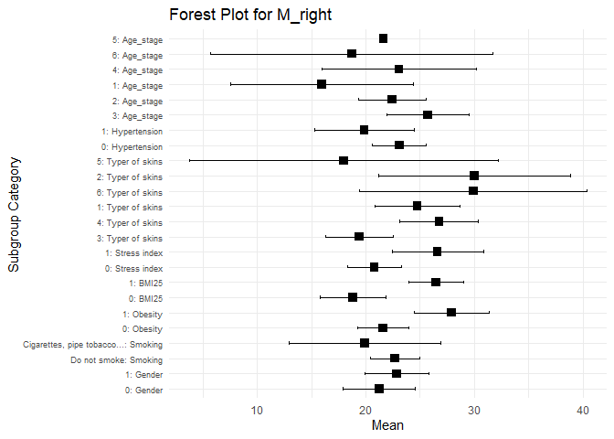

## Tạo bảng và Forest plot với biến Kv100_right

| Subgroup_Category | Subgroup | n_Kv100_right | Mean | CI_lower | CI_upper | P_Value |
| --- | --- | --- | --- | --- | --- | --- |
| Gender | 0 | 31 | 22.14626 | 17.6703903 | 26.62214 | 0.2961153 |
| Gender | 1 | 44 | 19.23460 | 15.6510430 | 22.81815 | 0.2961153 |
| Smoking | Do not smoke | 62 | 21.63233 | 18.4188013 | 24.84586 | 0.1474417 |
| Smoking | Cigarettes, pipe tobacco… | 13 | 14.74246 | 11.6345296 | 17.85039 | 0.1474417 |
| Obesity | 0 | 68 | 20.83542 | 17.8551032 | 23.81574 | 0.5179169 |
| Obesity | 1 | 7 | 16.57826 | 9.7953229 | 23.36120 | 0.5179169 |
| BMI25 | 0 | 42 | 24.06937 | 20.3114643 | 27.82728 | 0.0005078 |
| BMI25 | 1 | 33 | 15.81645 | 12.1754089 | 19.45749 | 0.0005078 |
| Stress index | 0 | 57 | 20.57171 | 17.3439292 | 23.79949 | 0.9258715 |
| Stress index | 1 | 18 | 20.01495 | 14.2258773 | 25.80403 | 0.9258715 |
| Typer of skins | 3 | 40 | 19.72226 | 15.8623151 | 23.58220 | NA |
| Typer of skins | 4 | 11 | 20.48197 | 13.5762321 | 27.38771 | NA |
| Typer of skins | 1 | 10 | 22.66645 | 12.1260173 | 33.20688 | NA |
| Typer of skins | 6 | 4 | 15.07250 | 0.7122165 | 29.43278 | NA |
| Typer of skins | 2 | 4 | 12.98000 | 3.2300125 | 22.72999 | NA |
| Typer of skins | 5 | 6 | 29.96500 | 18.5246333 | 41.40537 | NA |
| Hypertension | 0 | 54 | 21.71050 | 18.4573558 | 24.96364 | 0.0860008 |
| Hypertension | 1 | 21 | 17.16617 | 11.8244801 | 22.50785 | 0.0860008 |
| Age_stage | 3 | 13 | 15.31400 | 10.8606768 | 19.76732 | NA |
| Age_stage | 2 | 36 | 22.32660 | 18.1574832 | 26.49571 | NA |
| Age_stage | 1 | 7 | 23.24000 | 13.6358020 | 32.84420 | NA |
| Age_stage | 4 | 12 | 12.71183 | 8.7959514 | 16.62772 | NA |
| Age_stage | 6 | 6 | 31.10083 | 12.4376158 | 49.76405 | NA |
| Age_stage | 5 | 1 | 28.19000 | NaN | NaN | NA |

Wilcox pairwise test cho các sub group có >2 level

```
## Group Gender does not have more than 2 unique levels. Skipping.
```

```
## Group Smoking does not have more than 2 unique levels. Skipping.
```

```
## Group Obesity does not have more than 2 unique levels. Skipping.
```

```
## Group BMI25 does not have more than 2 unique levels. Skipping.
```

```
## Group Stress index does not have more than 2 unique levels. Skipping.
```

```
## Group Hypertension does not have more than 2 unique levels. Skipping.
```

| Group | Group1 | Group2 | P_Value |
| --- | --- | --- | --- |
| Typer of skins | 3 | 4 | 0.6595919 |
| Typer of skins | 3 | 1 | 0.6073440 |
| Typer of skins | 3 | 6 | 0.5947949 |
| Typer of skins | 3 | 2 | 0.3513786 |
| Typer of skins | 3 | 5 | 0.0594960 |
| Typer of skins | 4 | 1 | 0.9725388 |
| Typer of skins | 4 | 6 | 0.4893773 |
| Typer of skins | 4 | 2 | 0.3428571 |
| Typer of skins | 4 | 5 | 0.1489981 |
| Typer of skins | 1 | 6 | 0.4535465 |
| Typer of skins | 1 | 2 | 0.2397602 |
| Typer of skins | 1 | 5 | 0.2634865 |
| Typer of skins | 6 | 2 | 0.6857143 |
| Typer of skins | 6 | 5 | 0.0666667 |
| Typer of skins | 2 | 5 | 0.0380952 |
| Age_stage | 3 | 2 | 0.0791496 |
| Age_stage | 3 | 1 | 0.0674923 |
| Age_stage | 3 | 4 | 0.3760202 |
| Age_stage | 3 | 6 | 0.0715023 |
| Age_stage | 3 | 5 | 0.1428571 |
| Age_stage | 2 | 1 | 0.7353798 |
| Age_stage | 2 | 4 | 0.0123207 |
| Age_stage | 2 | 6 | 0.2076703 |
| Age_stage | 2 | 5 | 0.6486486 |
| Age_stage | 1 | 4 | 0.0358419 |
| Age_stage | 1 | 6 | 0.4452214 |
| Age_stage | 1 | 5 | 1.0000000 |
| Age_stage | 4 | 6 | 0.0244559 |
| Age_stage | 4 | 5 | 0.1538462 |
| Age_stage | 6 | 5 | 1.0000000 |

Forest plot

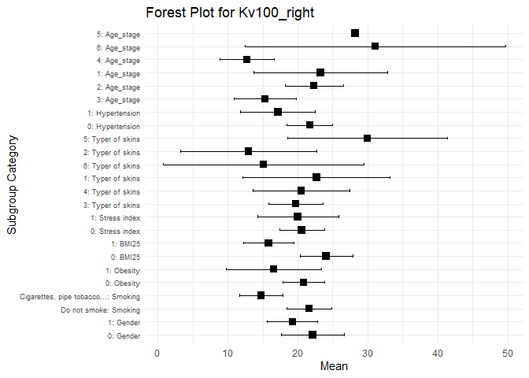

## Tạo bảng và Forest plot với biến δ_right

| Subgroup_Category | Subgroup | n_δ_right | Mean | CI_lower | CI_upper | P_Value |
| --- | --- | --- | --- | --- | --- | --- |
| Gender | 0 | 31 | 3.759113 | 3.0395029 | 4.478723 | 0.8464324 |
| Gender | 1 | 44 | 3.739992 | 3.1375649 | 4.342420 | 0.8464324 |
| Smoking | Do not smoke | 62 | 3.968890 | 3.4734691 | 4.464310 | 0.0484299 |
| Smoking | Cigarettes, pipe tobacco… | 13 | 2.693923 | 1.6666142 | 3.721232 | 0.0484299 |
| Obesity | 0 | 68 | 3.692735 | 3.2073660 | 4.178105 | 0.2949661 |
| Obesity | 1 | 7 | 4.283738 | 2.9391669 | 5.628309 | 0.2949661 |
| BMI25 | 0 | 42 | 3.887087 | 3.1889013 | 4.585273 | 0.8560102 |
| BMI25 | 1 | 33 | 3.570742 | 3.0219906 | 4.119494 | 0.8560102 |
| Stress index | 0 | 57 | 3.520901 | 2.9796547 | 4.062146 | 0.0365822 |
| Stress index | 1 | 18 | 4.466713 | 3.7130332 | 5.220393 | 0.0365822 |
| Typer of skins | 3 | 40 | 2.981442 | 2.4995401 | 3.463343 | NA |
| Typer of skins | 4 | 11 | 4.959242 | 3.5355258 | 6.382959 | NA |
| Typer of skins | 1 | 10 | 4.728283 | 3.4358848 | 6.020682 | NA |
| Typer of skins | 6 | 4 | 4.197500 | 1.5782940 | 6.816706 | NA |
| Typer of skins | 2 | 4 | 3.975000 | 0.6377911 | 7.312209 | NA |
| Typer of skins | 5 | 6 | 4.551667 | 1.3685402 | 7.734793 | NA |
| Hypertension | 0 | 54 | 4.173475 | 3.6265207 | 4.720430 | 0.0029424 |
| Hypertension | 1 | 21 | 2.653548 | 2.0382055 | 3.268890 | 0.0029424 |
| Age_stage | 3 | 13 | 3.574000 | 2.5558187 | 4.592181 | NA |
| Age_stage | 2 | 36 | 4.107801 | 3.4420057 | 4.773596 | NA |
| Age_stage | 1 | 7 | 3.202857 | 1.2887320 | 5.116982 | NA |
| Age_stage | 4 | 12 | 2.643417 | 1.5247414 | 3.762092 | NA |
| Age_stage | 6 | 6 | 4.416389 | 2.0755936 | 6.757184 | NA |
| Age_stage | 5 | 1 | 6.110000 | NaN | NaN | NA |

Wilcox pairwise test cho các sub group có >2 level

```
## Group Gender does not have more than 2 unique levels. Skipping.
```

```
## Group Smoking does not have more than 2 unique levels. Skipping.
```

```
## Group Obesity does not have more than 2 unique levels. Skipping.
```

```
## Group BMI25 does not have more than 2 unique levels. Skipping.
```

```
## Group Stress index does not have more than 2 unique levels. Skipping.
```

```
## Group Hypertension does not have more than 2 unique levels. Skipping.
```

| Group | Group1 | Group2 | P_Value |
| --- | --- | --- | --- |
| Typer of skins | 3 | 4 | 0.0053907 |
| Typer of skins | 3 | 1 | 0.0059020 |
| Typer of skins | 3 | 6 | 0.1361549 |
| Typer of skins | 3 | 2 | 0.3582757 |
| Typer of skins | 3 | 5 | 0.2745033 |
| Typer of skins | 4 | 1 | 1.0000000 |
| Typer of skins | 4 | 6 | 0.7531136 |
| Typer of skins | 4 | 2 | 0.4893773 |
| Typer of skins | 4 | 5 | 0.8075307 |
| Typer of skins | 1 | 6 | 0.7332667 |
| Typer of skins | 1 | 2 | 0.6353646 |
| Typer of skins | 1 | 5 | 0.8748751 |
| Typer of skins | 6 | 2 | 1.0000000 |
| Typer of skins | 6 | 5 | 0.9142857 |
| Typer of skins | 2 | 5 | 1.0000000 |
| Age_stage | 3 | 2 | 0.4345844 |
| Age_stage | 3 | 1 | 0.5880289 |
| Age_stage | 3 | 4 | 0.1860700 |
| Age_stage | 3 | 6 | 0.5788737 |
| Age_stage | 3 | 5 | 0.2857143 |
| Age_stage | 2 | 1 | 0.2172951 |
| Age_stage | 2 | 4 | 0.0311713 |
| Age_stage | 2 | 6 | 0.7058427 |
| Age_stage | 2 | 5 | 0.2060360 |
| Age_stage | 1 | 4 | 0.5539392 |
| Age_stage | 1 | 6 | 0.2948718 |
| Age_stage | 1 | 5 | 0.5000000 |
| Age_stage | 4 | 6 | 0.1024564 |
| Age_stage | 4 | 5 | 0.1538462 |
| Age_stage | 6 | 5 | 0.5714286 |

Forest plot

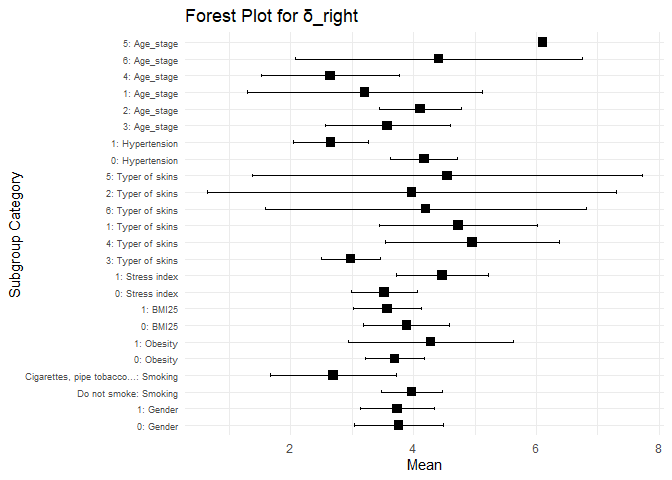

## Tạo bảng và Forest plot với biến T_right

| Subgroup_Category | Subgroup | n_T_right | Mean | CI_lower | CI_upper | P_Value |
| --- | --- | --- | --- | --- | --- | --- |
| Gender | 0 | 31 | 31.67831 | 30.55601 | 32.80060 | 0.9485282 |
| Gender | 1 | 44 | 30.95224 | 29.65568 | 32.24880 | 0.9485282 |
| Smoking | Do not smoke | 62 | 31.57658 | 30.70930 | 32.44386 | 0.3447796 |
| Smoking | Cigarettes, pipe tobacco… | 13 | 29.70600 | 26.56882 | 32.84318 | 0.3447796 |
| Obesity | 0 | 68 | 30.98938 | 30.05308 | 31.92569 | 0.0370332 |
| Obesity | 1 | 7 | 33.80688 | 32.13656 | 35.47721 | 0.0370332 |
| BMI25 | 0 | 42 | 30.28253 | 29.08138 | 31.48369 | 0.0029533 |
| BMI25 | 1 | 33 | 32.48666 | 31.27519 | 33.69814 | 0.0029533 |
| Stress index | 0 | 57 | 30.69375 | 29.60894 | 31.77856 | 0.0645423 |
| Stress index | 1 | 18 | 33.02125 | 32.06923 | 33.97327 | 0.0645423 |
| Typer of skins | 3 | 40 | 30.34933 | 29.07439 | 31.62426 | NA |
| Typer of skins | 4 | 11 | 33.28576 | 32.32459 | 34.24692 | NA |
| Typer of skins | 1 | 10 | 32.77298 | 31.21049 | 34.33548 | NA |
| Typer of skins | 6 | 4 | 34.86250 | 33.04324 | 36.68176 | NA |
| Typer of skins | 2 | 4 | 32.20750 | 24.01163 | 40.40337 | NA |
| Typer of skins | 5 | 6 | 27.96667 | 23.66553 | 32.26780 | NA |
| Hypertension | 0 | 54 | 31.69583 | 30.80213 | 32.58953 | 0.4189196 |
| Hypertension | 1 | 21 | 30.11198 | 27.91394 | 32.31001 | 0.4189196 |
| Age_stage | 3 | 13 | 32.42108 | 30.88051 | 33.96165 | NA |
| Age_stage | 2 | 36 | 31.53044 | 30.37106 | 32.68982 | NA |
| Age_stage | 1 | 7 | 28.53429 | 25.06732 | 32.00125 | NA |
| Age_stage | 4 | 12 | 31.26067 | 28.10936 | 34.41198 | NA |
| Age_stage | 6 | 6 | 29.68639 | 24.29564 | 35.07714 | NA |
| Age_stage | 5 | 1 | 34.37000 | NaN | NaN | NA |

Wilcox pairwise test cho các sub group có >2 level

```
## Group Gender does not have more than 2 unique levels. Skipping.
```

```
## Group Smoking does not have more than 2 unique levels. Skipping.
```

```
## Group Obesity does not have more than 2 unique levels. Skipping.
```

```
## Group BMI25 does not have more than 2 unique levels. Skipping.
```

```
## Group Stress index does not have more than 2 unique levels. Skipping.
```

```
## Group Hypertension does not have more than 2 unique levels. Skipping.
```

| Group | Group1 | Group2 | P_Value |
| --- | --- | --- | --- |
| Typer of skins | 3 | 4 | 0.0414975 |
| Typer of skins | 3 | 1 | 0.0895474 |
| Typer of skins | 3 | 6 | 0.0063499 |
| Typer of skins | 3 | 2 | 0.2556003 |
| Typer of skins | 3 | 5 | 0.1597806 |
| Typer of skins | 4 | 1 | 0.8632668 |
| Typer of skins | 4 | 6 | 0.0776557 |
| Typer of skins | 4 | 2 | 0.7531136 |
| Typer of skins | 4 | 5 | 0.0019392 |
| Typer of skins | 1 | 6 | 0.1058941 |
| Typer of skins | 1 | 2 | 0.8391608 |
| Typer of skins | 1 | 5 | 0.0224775 |
| Typer of skins | 6 | 2 | 0.6857143 |
| Typer of skins | 6 | 5 | 0.0095238 |
| Typer of skins | 2 | 5 | 0.1714286 |
| Age_stage | 3 | 2 | 0.6145708 |
| Age_stage | 3 | 1 | 0.0236068 |
| Age_stage | 3 | 4 | 0.9786974 |
| Age_stage | 3 | 6 | 0.3676102 |
| Age_stage | 3 | 5 | 0.7142857 |
| Age_stage | 2 | 1 | 0.0487462 |
| Age_stage | 2 | 4 | 0.5644657 |
| Age_stage | 2 | 6 | 0.4503330 |
| Age_stage | 2 | 5 | 0.3783784 |
| Age_stage | 1 | 4 | 0.2614114 |
| Age_stage | 1 | 6 | 0.8356643 |
| Age_stage | 1 | 5 | 0.5000000 |
| Age_stage | 4 | 6 | 0.7502693 |
| Age_stage | 4 | 5 | 0.9230769 |
| Age_stage | 6 | 5 | 0.8571429 |

Forest plot

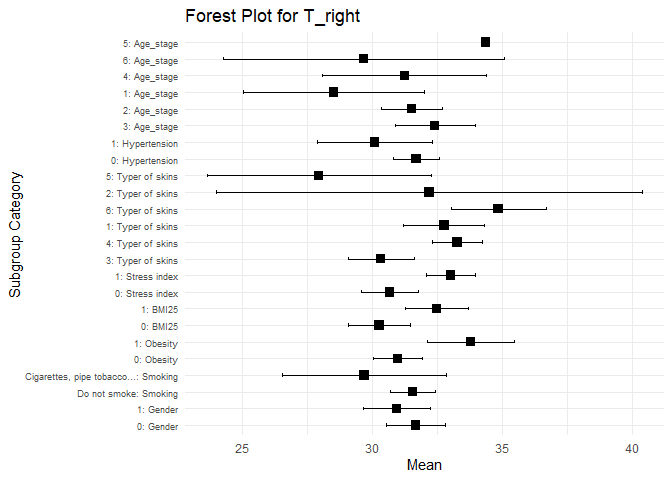

## Tạo bảng và Forest plot với biến A365_right

| Subgroup_Category | Subgroup | n_A365_right | Mean | CI_lower | CI_upper | P_Value |
| --- | --- | --- | --- | --- | --- | --- |
| Gender | 0 | 31 | 84.00806 | 70.460991 | 97.55514 | 0.9015111 |
| Gender | 1 | 44 | 83.52348 | 72.886340 | 94.16063 | 0.9015111 |
| Smoking | Do not smoke | 62 | 83.81909 | 75.030220 | 92.60795 | 0.9163818 |
| Smoking | Cigarettes, pipe tobacco… | 13 | 83.26923 | 58.294200 | 108.24426 | 0.9163818 |
| Obesity | 0 | 68 | 82.48529 | 73.621831 | 91.34876 | 0.4281217 |
| Obesity | 1 | 7 | 95.75476 | 76.481498 | 115.02803 | 0.4281217 |
| BMI25 | 0 | 42 | 84.09921 | 72.172329 | 96.02608 | 0.7007465 |
| BMI25 | 1 | 33 | 83.24596 | 71.775013 | 94.71691 | 0.7007465 |
| Stress index | 0 | 57 | 84.79591 | 75.450514 | 94.14130 | 0.6022815 |
| Stress index | 1 | 18 | 80.32870 | 61.713941 | 98.94347 | 0.6022815 |
| Typer of skins | 3 | 40 | 92.39167 | 83.164459 | 101.61887 | NA |
| Typer of skins | 4 | 11 | 89.13636 | 70.510711 | 107.76202 | NA |
| Typer of skins | 1 | 10 | 105.61167 | 93.237087 | 117.98625 | NA |
| Typer of skins | 6 | 4 | 22.75000 | -19.796006 | 65.29601 | NA |
| Typer of skins | 2 | 4 | 61.50000 | -3.985487 | 126.98549 | NA |
| Typer of skins | 5 | 6 | 35.00000 | 4.283609 | 65.71639 | NA |
| Hypertension | 0 | 54 | 81.45062 | 71.695839 | 91.20540 | 0.3792641 |
| Hypertension | 1 | 21 | 89.56905 | 73.516903 | 105.62119 | 0.3792641 |
| Age_stage | 3 | 13 | 80.47692 | 60.869638 | 100.08421 | NA |
| Age_stage | 2 | 36 | 86.38657 | 74.075530 | 98.69762 | NA |
| Age_stage | 1 | 7 | 82.92857 | 42.703603 | 123.15354 | NA |
| Age_stage | 4 | 12 | 83.04167 | 57.199270 | 108.88406 | NA |
| Age_stage | 6 | 6 | 85.86111 | 65.753038 | 105.96918 | NA |
| Age_stage | 5 | 1 | 31.00000 | NaN | NaN | NA |

Wilcox pairwise test cho các sub group có >2 level

```
## Group Gender does not have more than 2 unique levels. Skipping.
```

```
## Group Smoking does not have more than 2 unique levels. Skipping.
```

```
## Group Obesity does not have more than 2 unique levels. Skipping.
```

```
## Group BMI25 does not have more than 2 unique levels. Skipping.
```

```
## Group Stress index does not have more than 2 unique levels. Skipping.
```

```
## Group Hypertension does not have more than 2 unique levels. Skipping.
```

| Group | Group1 | Group2 | P_Value |
| --- | --- | --- | --- |
| Typer of skins | 3 | 4 | 0.6884722 |
| Typer of skins | 3 | 1 | 0.1630617 |
| Typer of skins | 3 | 6 | 0.0030721 |
| Typer of skins | 3 | 2 | 0.1067244 |
| Typer of skins | 3 | 5 | 0.0017371 |
| Typer of skins | 4 | 1 | 0.1971161 |
| Typer of skins | 4 | 6 | 0.0102564 |
| Typer of skins | 4 | 2 | 0.1912977 |
| Typer of skins | 4 | 5 | 0.0030705 |
| Typer of skins | 1 | 6 | 0.0019980 |
| Typer of skins | 1 | 2 | 0.1418581 |
| Typer of skins | 1 | 5 | 0.0004995 |
| Typer of skins | 6 | 2 | 0.2000000 |
| Typer of skins | 6 | 5 | 0.4761905 |
| Typer of skins | 2 | 5 | 0.4761905 |
| Age_stage | 3 | 2 | 0.4616514 |
| Age_stage | 3 | 1 | 0.8772962 |
| Age_stage | 3 | 4 | 0.6832555 |
| Age_stage | 3 | 6 | 0.9660917 |
| Age_stage | 3 | 5 | 0.2857143 |
| Age_stage | 2 | 1 | 0.9606358 |
| Age_stage | 2 | 4 | 0.8209721 |
| Age_stage | 2 | 6 | 0.7192204 |
| Age_stage | 2 | 5 | 0.1743714 |
| Age_stage | 1 | 4 | 0.7350929 |
| Age_stage | 1 | 6 | 0.8356643 |
| Age_stage | 1 | 5 | 0.7500000 |
| Age_stage | 4 | 6 | 0.7429311 |
| Age_stage | 4 | 5 | 0.3489119 |
| Age_stage | 6 | 5 | 0.2857143 |

Forest plot

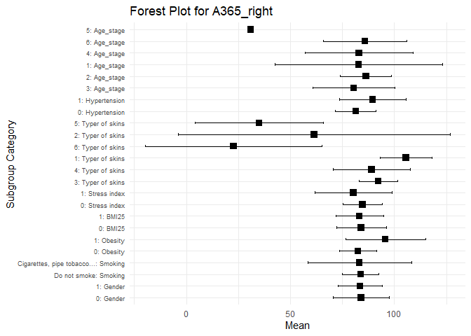

## Tạo bảng và Forest plot với biến A460_right

| Subgroup_Category | Subgroup | n_A460_right | Mean | CI_lower | CI_upper | P_Value |
| --- | --- | --- | --- | --- | --- | --- |
| Gender | 0 | 31 | 49.41935 | 42.1410761 | 56.69763 | 0.8675353 |
| Gender | 1 | 44 | 50.37348 | 43.8870706 | 56.85990 | 0.8675353 |
| Smoking | Do not smoke | 62 | 49.33925 | 44.7553080 | 53.92319 | 0.4623910 |
| Smoking | Cigarettes, pipe tobacco… | 13 | 53.03077 | 34.4217304 | 71.63981 | 0.4623910 |
| Obesity | 0 | 68 | 49.96176 | 44.7493050 | 55.17422 | 0.9491658 |
| Obesity | 1 | 7 | 50.14762 | 43.2830809 | 57.01216 | 0.9491658 |
| BMI25 | 0 | 42 | 51.11270 | 43.6003928 | 58.62500 | 0.4810942 |
| BMI25 | 1 | 33 | 48.53636 | 43.1256571 | 53.94707 | 0.4810942 |
| Stress index | 0 | 57 | 50.80292 | 45.5308648 | 56.07498 | 0.7376304 |
| Stress index | 1 | 18 | 47.37037 | 35.8450519 | 58.89569 | 0.7376304 |
| Typer of skins | 3 | 40 | 58.95583 | 53.3578921 | 64.55377 | NA |
| Typer of skins | 4 | 11 | 50.66667 | 38.7709225 | 62.56241 | NA |
| Typer of skins | 1 | 10 | 47.13667 | 40.5349731 | 53.73836 | NA |
| Typer of skins | 6 | 4 | 11.25000 | -0.8944836 | 23.39448 | NA |
| Typer of skins | 2 | 4 | 46.00000 | 24.7307167 | 67.26928 | NA |
| Typer of skins | 5 | 6 | 22.08333 | 8.8237787 | 35.34289 | NA |
| Hypertension | 0 | 54 | 47.43025 | 42.0537935 | 52.80670 | 0.0996986 |
| Hypertension | 1 | 21 | 56.53333 | 46.5688520 | 66.49781 | 0.0996986 |
| Age_stage | 3 | 13 | 51.16923 | 43.0457133 | 59.29275 | NA |
| Age_stage | 2 | 36 | 46.61574 | 39.6203561 | 53.61113 | NA |
| Age_stage | 1 | 7 | 57.57143 | 38.1268747 | 77.01598 | NA |
| Age_stage | 4 | 12 | 57.61667 | 42.5116758 | 72.72166 | NA |
| Age_stage | 6 | 6 | 48.44444 | 22.9089759 | 73.97991 | NA |
| Age_stage | 5 | 1 | 20.00000 | NaN | NaN | NA |

Wilcox pairwise test cho các sub group có >2 level

```
## Group Gender does not have more than 2 unique levels. Skipping.
```

```
## Group Smoking does not have more than 2 unique levels. Skipping.
```

```
## Group Obesity does not have more than 2 unique levels. Skipping.
```

```
## Group BMI25 does not have more than 2 unique levels. Skipping.
```

```
## Group Stress index does not have more than 2 unique levels. Skipping.
```

```
## Group Hypertension does not have more than 2 unique levels. Skipping.
```

| Group | Group1 | Group2 | P_Value |
| --- | --- | --- | --- |
| Typer of skins | 3 | 4 | 0.1728809 |
| Typer of skins | 3 | 1 | 0.0427798 |
| Typer of skins | 3 | 6 | 0.0011679 |
| Typer of skins | 3 | 2 | 0.1588343 |
| Typer of skins | 3 | 5 | 0.0004256 |
| Typer of skins | 4 | 1 | 0.8602139 |
| Typer of skins | 4 | 6 | 0.0049617 |
| Typer of skins | 4 | 2 | 0.9479053 |
| Typer of skins | 4 | 5 | 0.0056827 |
| Typer of skins | 1 | 6 | 0.0019980 |
| Typer of skins | 1 | 2 | 0.8391608 |
| Typer of skins | 1 | 5 | 0.0017483 |
| Typer of skins | 6 | 2 | 0.0285714 |
| Typer of skins | 6 | 5 | 0.1714286 |
| Typer of skins | 2 | 5 | 0.0190476 |
| Age_stage | 3 | 2 | 0.4019872 |
| Age_stage | 3 | 1 | 0.3215481 |
| Age_stage | 3 | 4 | 0.1417096 |
| Age_stage | 3 | 6 | 0.7587634 |
| Age_stage | 3 | 5 | 0.1362097 |
| Age_stage | 2 | 1 | 0.2234367 |
| Age_stage | 2 | 4 | 0.1160138 |
| Age_stage | 2 | 6 | 0.9426837 |
| Age_stage | 2 | 5 | 0.1743969 |
| Age_stage | 1 | 4 | 0.9662785 |
| Age_stage | 1 | 6 | 0.4452214 |
| Age_stage | 1 | 5 | 0.2500000 |
| Age_stage | 4 | 6 | 0.3251534 |
| Age_stage | 4 | 5 | 0.2284617 |
| Age_stage | 6 | 5 | 0.5714286 |

Forest plot

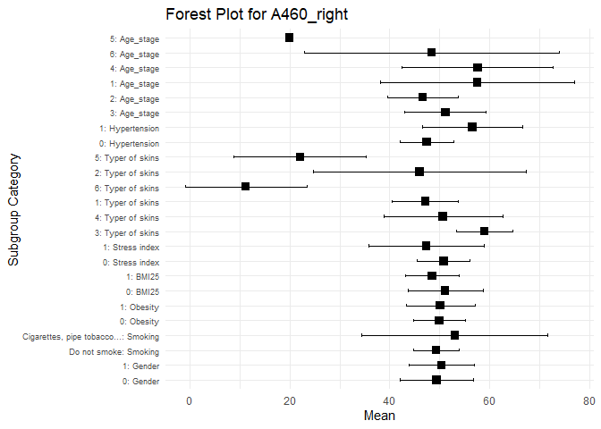

## Tạo bảng và Forest plot với biến Anadn_right

| Subgroup_Category | Subgroup | n_Anadn_right | Mean | CI_lower | CI_upper | P_Value |
| --- | --- | --- | --- | --- | --- | --- |
| Gender | 0 | 31 | 0.9841398 | 0.5201697 | 1.4481099 | 0.6984398 |
| Gender | 1 | 44 | 0.7017500 | 0.6008722 | 0.8026278 | 0.6984398 |
| Smoking | Do not smoke | 62 | 0.8281989 | 0.5935062 | 1.0628917 | 0.3591432 |
| Smoking | Cigarettes, pipe tobacco… | 13 | 0.7720769 | 0.5222217 | 1.0219321 | 0.3591432 |
| Obesity | 0 | 68 | 0.8387549 | 0.6231533 | 1.0543565 | 0.2783877 |
| Obesity | 1 | 7 | 0.6214286 | 0.2995797 | 0.9432775 | 0.2783877 |
| BMI25 | 0 | 42 | 0.8071905 | 0.5859515 | 1.0284295 | 0.7528030 |
| BMI25 | 1 | 33 | 0.8328283 | 0.4699968 | 1.1956597 | 0.7528030 |
| Stress index | 0 | 57 | 0.7966140 | 0.5688017 | 1.0244263 | 0.8816304 |
| Stress index | 1 | 18 | 0.8876852 | 0.4563599 | 1.3190105 | 0.8816304 |
| Typer of skins | 3 | 40 | 0.8589667 | 0.5387906 | 1.1791428 | NA |
| Typer of skins | 4 | 11 | 0.6413636 | 0.4460327 | 0.8366946 | NA |
| Typer of skins | 1 | 10 | 0.4581667 | 0.3806902 | 0.5356432 | NA |
| Typer of skins | 6 | 4 | 1.6600000 | -0.9972950 | 4.3172950 | NA |
| Typer of skins | 2 | 4 | 0.9475000 | 0.2566605 | 1.6383395 | NA |
| Typer of skins | 5 | 6 | 0.8266667 | 0.4618060 | 1.1915273 | NA |
| Hypertension | 0 | 54 | 0.7549136 | 0.5806354 | 0.9291918 | 0.2402396 |
| Hypertension | 1 | 21 | 0.9819048 | 0.4079518 | 1.5558577 | 0.2402396 |
| Age_stage | 3 | 13 | 0.7780769 | 0.5603195 | 0.9958344 | NA |
| Age_stage | 2 | 36 | 0.7186574 | 0.5005082 | 0.9368066 | NA |
| Age_stage | 1 | 7 | 1.0114286 | 0.0703148 | 1.9525423 | NA |
| Age_stage | 4 | 12 | 1.2055833 | 0.1784954 | 2.2326713 | NA |
| Age_stage | 6 | 6 | 0.5352778 | 0.3434851 | 0.7270705 | NA |
| Age_stage | 5 | 1 | 0.6400000 | NaN | NaN | NA |

Wilcox pairwise test cho các sub group có >2 level

```
## Group Gender does not have more than 2 unique levels. Skipping.
```

```
## Group Smoking does not have more than 2 unique levels. Skipping.
```

```
## Group Obesity does not have more than 2 unique levels. Skipping.
```

```
## Group BMI25 does not have more than 2 unique levels. Skipping.
```

```
## Group Stress index does not have more than 2 unique levels. Skipping.
```

```
## Group Hypertension does not have more than 2 unique levels. Skipping.
```

| Group | Group1 | Group2 | P_Value |
| --- | --- | --- | --- |
| Typer of skins | 3 | 4 | 0.3246317 |
| Typer of skins | 3 | 1 | 0.0081836 |
| Typer of skins | 3 | 6 | 0.5266993 |
| Typer of skins | 3 | 2 | 0.3371101 |
| Typer of skins | 3 | 5 | 0.5246100 |
| Typer of skins | 4 | 1 | 0.0971976 |
| Typer of skins | 4 | 6 | 0.3428571 |
| Typer of skins | 4 | 2 | 0.1377289 |
| Typer of skins | 4 | 5 | 0.1801875 |
| Typer of skins | 1 | 6 | 0.1366985 |
| Typer of skins | 1 | 2 | 0.0131260 |
| Typer of skins | 1 | 5 | 0.0056067 |
| Typer of skins | 6 | 2 | 0.7715034 |
| Typer of skins | 6 | 5 | 0.6095238 |
| Typer of skins | 2 | 5 | 0.6688699 |
| Age_stage | 3 | 2 | 0.1635813 |
| Age_stage | 3 | 1 | 1.0000000 |
| Age_stage | 3 | 4 | 0.6631548 |
| Age_stage | 3 | 6 | 0.2030709 |
| Age_stage | 3 | 5 | 1.0000000 |
| Age_stage | 2 | 1 | 0.1771390 |
| Age_stage | 2 | 4 | 0.0350457 |
| Age_stage | 2 | 6 | 0.7326453 |
| Age_stage | 2 | 5 | 0.6731975 |
| Age_stage | 1 | 4 | 0.4218309 |
| Age_stage | 1 | 6 | 0.1309390 |
| Age_stage | 1 | 5 | 1.0000000 |
| Age_stage | 4 | 6 | 0.0439362 |
| Age_stage | 4 | 5 | 0.7889848 |
| Age_stage | 6 | 5 | 0.4491772 |

Forest plot

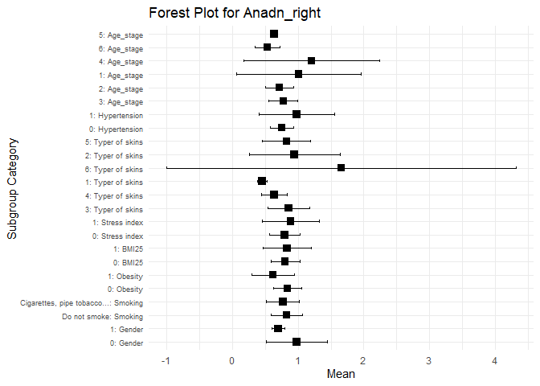

## Tạo bảng và Forest plot với biến POM_right

| Subgroup_Category | Subgroup | n_POM_right | Mean | CI_lower | CI_upper | P_Value |
| --- | --- | --- | --- | --- | --- | --- |
| Gender | 0 | 31 | 9.333307 | 6.5181818 | 12.148431 | 0.5243332 |
| Gender | 1 | 44 | 9.375091 | 7.5999330 | 11.150249 | 0.5243332 |
| Smoking | Do not smoke | 62 | 9.604105 | 8.0018694 | 11.206340 | 0.1954352 |
| Smoking | Cigarettes, pipe tobacco… | 13 | 8.183231 | 3.3013657 | 13.065096 | 0.1954352 |
| Obesity | 0 | 68 | 9.174147 | 7.5183953 | 10.829899 | 0.1377146 |
| Obesity | 1 | 7 | 11.142071 | 7.9081111 | 14.376032 | 0.1377146 |
| BMI25 | 0 | 42 | 7.952032 | 6.0110340 | 9.893030 | 0.0190622 |
| BMI25 | 1 | 33 | 11.147005 | 8.7570700 | 13.536940 | 0.0190622 |
| Stress index | 0 | 57 | 8.834222 | 7.1473276 | 10.521117 | 0.2079775 |
| Stress index | 1 | 18 | 11.015880 | 7.3886237 | 14.643136 | 0.2079775 |
| Typer of skins | 3 | 40 | 7.432800 | 5.9666659 | 8.898934 | NA |
| Typer of skins | 4 | 11 | 12.411970 | 7.7448214 | 17.079118 | NA |
| Typer of skins | 1 | 10 | 14.578283 | 8.6443174 | 20.512249 | NA |
| Typer of skins | 6 | 4 | 11.142500 | -9.0216749 | 31.306675 | NA |
| Typer of skins | 2 | 4 | 10.450000 | 1.2285632 | 19.671437 | NA |
| Typer of skins | 5 | 6 | 5.973333 | 0.8451700 | 11.101497 | NA |
| Hypertension | 0 | 54 | 10.389019 | 8.4695532 | 12.308484 | 0.0362175 |
| Hypertension | 1 | 21 | 6.706167 | 4.6530367 | 8.759297 | 0.0362175 |
| Age_stage | 3 | 13 | 9.041692 | 6.5681627 | 11.515222 | NA |
| Age_stage | 2 | 36 | 10.516366 | 8.0125395 | 13.020192 | NA |
| Age_stage | 1 | 7 | 6.528571 | 1.8739307 | 11.183212 | NA |
| Age_stage | 4 | 12 | 7.198500 | 3.9022661 | 10.494734 | NA |
| Age_stage | 6 | 6 | 10.533889 | 0.0788159 | 20.988962 | NA |
| Age_stage | 5 | 1 | 10.420000 | NaN | NaN | NA |

Wilcox pairwise test cho các sub group có >2 level

```
## Group Gender does not have more than 2 unique levels. Skipping.
```

```
## Group Smoking does not have more than 2 unique levels. Skipping.
```

```
## Group Obesity does not have more than 2 unique levels. Skipping.
```

```
## Group BMI25 does not have more than 2 unique levels. Skipping.
```

```
## Group Stress index does not have more than 2 unique levels. Skipping.
```

```
## Group Hypertension does not have more than 2 unique levels. Skipping.
```

| Group | Group1 | Group2 | P_Value |
| --- | --- | --- | --- |
| Typer of skins | 3 | 4 | 0.0308317 |
| Typer of skins | 3 | 1 | 0.0022498 |
| Typer of skins | 3 | 6 | 0.8904244 |
| Typer of skins | 3 | 2 | 0.3307379 |
| Typer of skins | 3 | 5 | 0.4928111 |
| Typer of skins | 4 | 1 | 0.3866794 |
| Typer of skins | 4 | 6 | 0.4893773 |
| Typer of skins | 4 | 2 | 0.8512821 |
| Typer of skins | 4 | 5 | 0.1215255 |
| Typer of skins | 1 | 6 | 0.2397602 |
| Typer of skins | 1 | 2 | 0.6353646 |
| Typer of skins | 1 | 5 | 0.0109890 |
| Typer of skins | 6 | 2 | 0.6857143 |
| Typer of skins | 6 | 5 | 0.6095238 |
| Typer of skins | 2 | 5 | 0.2571429 |
| Age_stage | 3 | 2 | 0.6954337 |
| Age_stage | 3 | 1 | 0.3113777 |
| Age_stage | 3 | 4 | 0.3203219 |
| Age_stage | 3 | 6 | 0.8982751 |
| Age_stage | 3 | 5 | 0.8571429 |
| Age_stage | 2 | 1 | 0.1984224 |
| Age_stage | 2 | 4 | 0.0983976 |
| Age_stage | 2 | 6 | 0.7658166 |
| Age_stage | 2 | 5 | 0.9189189 |
| Age_stage | 1 | 4 | 0.9671350 |
| Age_stage | 1 | 6 | 0.6282051 |
| Age_stage | 1 | 5 | 0.7500000 |
| Age_stage | 4 | 6 | 0.6819651 |
| Age_stage | 4 | 5 | 0.6153846 |
| Age_stage | 6 | 5 | 0.8571429 |

Forest plot

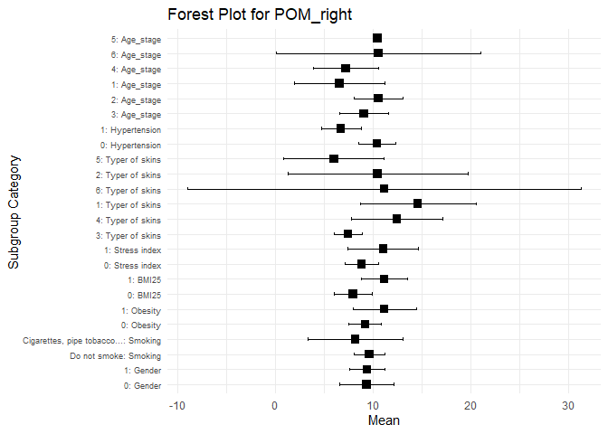

## Tạo bảng và Forest plot với biến Ae_right

| Subgroup_Category | Subgroup | n_Ae_right | Mean | CI_lower | CI_upper | P_Value |
| --- | --- | --- | --- | --- | --- | --- |
| Gender | 0 | 31 | 1.2738172 | 1.0220175 | 1.525617 | 0.5831796 |
| Gender | 1 | 44 | 1.4415606 | 1.1625006 | 1.720621 | 0.5831796 |
| Smoking | Do not smoke | 62 | 1.4347419 | 1.2267301 | 1.642754 | 0.0957799 |
| Smoking | Cigarettes, pipe tobacco… | 13 | 1.0740769 | 0.5639245 | 1.584229 | 0.0957799 |
| Obesity | 0 | 68 | 1.3359020 | 1.1334771 | 1.538327 | 0.1777114 |
| Obesity | 1 | 7 | 1.7250952 | 1.0649719 | 2.385219 | 0.1777114 |
| BMI25 | 0 | 42 | 1.4222937 | 1.1344551 | 1.710132 | 0.8267927 |
| BMI25 | 1 | 33 | 1.3085051 | 1.0604805 | 1.556530 | 0.8267927 |
| Stress index | 0 | 57 | 1.3136316 | 1.0835936 | 1.543670 | 0.1449190 |
| Stress index | 1 | 18 | 1.5577778 | 1.2172949 | 1.898261 | 0.1449190 |
| Typer of skins | 3 | 40 | 1.1565333 | 0.9266590 | 1.386408 | NA |
| Typer of skins | 4 | 11 | 1.7024242 | 1.1454099 | 2.259439 | NA |
| Typer of skins | 1 | 10 | 1.7754000 | 1.2061797 | 2.344620 | NA |
| Typer of skins | 6 | 4 | 1.3550000 | 0.4390210 | 2.270979 | NA |
| Typer of skins | 2 | 4 | 1.1825000 | -0.0172566 | 2.382257 | NA |
| Typer of skins | 5 | 6 | 1.6708333 | 0.1800975 | 3.161569 | NA |
| Hypertension | 0 | 54 | 1.5272778 | 1.2942126 | 1.760343 | 0.0064121 |
| Hypertension | 1 | 21 | 0.9735238 | 0.6929820 | 1.254066 | 0.0064121 |
| Age_stage | 3 | 13 | 1.3399231 | 0.9785202 | 1.701326 | NA |
| Age_stage | 2 | 36 | 1.4844444 | 1.1801782 | 1.788711 | NA |
| Age_stage | 1 | 7 | 1.0542857 | 0.3648391 | 1.743732 | NA |
| Age_stage | 4 | 12 | 1.1269167 | 0.5710111 | 1.682822 | NA |
| Age_stage | 6 | 6 | 1.5108333 | 0.5723292 | 2.449337 | NA |
| Age_stage | 5 | 1 | 2.0900000 | NaN | NaN | NA |

Wilcox pairwise test cho các sub group có >2 level

```
## Group Gender does not have more than 2 unique levels. Skipping.
```

```
## Group Smoking does not have more than 2 unique levels. Skipping.
```

```
## Group Obesity does not have more than 2 unique levels. Skipping.
```

```
## Group BMI25 does not have more than 2 unique levels. Skipping.
```

```
## Group Stress index does not have more than 2 unique levels. Skipping.
```

```
## Group Hypertension does not have more than 2 unique levels. Skipping.
```

| Group | Group1 | Group2 | P_Value |
| --- | --- | --- | --- |
| Typer of skins | 3 | 4 | 0.0392730 |
| Typer of skins | 3 | 1 | 0.0318255 |
| Typer of skins | 3 | 6 | 0.4378782 |
| Typer of skins | 3 | 2 | 1.0000000 |
| Typer of skins | 3 | 5 | 0.5141377 |
| Typer of skins | 4 | 1 | 0.6047302 |
| Typer of skins | 4 | 6 | 0.5714286 |
| Typer of skins | 4 | 2 | 0.3603361 |
| Typer of skins | 4 | 5 | 0.8075307 |
| Typer of skins | 1 | 6 | 0.3036963 |
| Typer of skins | 1 | 2 | 0.2397602 |
| Typer of skins | 1 | 5 | 0.6353646 |
| Typer of skins | 6 | 2 | 0.8857143 |
| Typer of skins | 6 | 5 | 1.0000000 |
| Typer of skins | 2 | 5 | 0.9142857 |
| Age_stage | 3 | 2 | 0.9188259 |
| Age_stage | 3 | 1 | 0.2749226 |
| Age_stage | 3 | 4 | 0.3012939 |
| Age_stage | 3 | 6 | 0.7256055 |
| Age_stage | 3 | 5 | 0.2857143 |
| Age_stage | 2 | 1 | 0.2362184 |
| Age_stage | 2 | 4 | 0.1398498 |
| Age_stage | 2 | 6 | 0.7192204 |
| Age_stage | 2 | 5 | 0.3735117 |
| Age_stage | 1 | 4 | 0.9018020 |
| Age_stage | 1 | 6 | 0.3659674 |
| Age_stage | 1 | 5 | 0.5000000 |
| Age_stage | 4 | 6 | 0.3354880 |
| Age_stage | 4 | 5 | 0.6153846 |
| Age_stage | 6 | 5 | 0.8571429 |

Forest plot

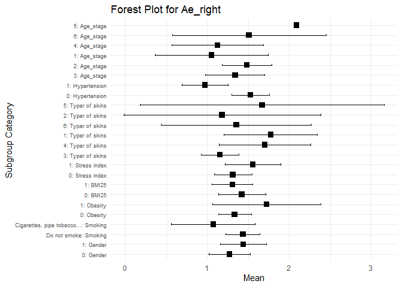

## Tạo bảng và Forest plot với biến An_right

| Subgroup_Category | Subgroup | n_An_right | Mean | CI_lower | CI_upper | P_Value |
| --- | --- | --- | --- | --- | --- | --- |
| Gender | 0 | 31 | 1.2481183 | 1.0020757 | 1.494161 | 0.5290407 |
| Gender | 1 | 44 | 1.4019318 | 1.1506090 | 1.653255 | 0.5290407 |
| Smoking | Do not smoke | 62 | 1.3915108 | 1.2033743 | 1.579647 | 0.1044305 |
| Smoking | Cigarettes, pipe tobacco… | 13 | 1.0848462 | 0.5666955 | 1.602997 | 0.1044305 |
| Obesity | 0 | 68 | 1.3069804 | 1.1204915 | 1.493469 | 0.1836244 |
| Obesity | 1 | 7 | 1.6431429 | 1.0086460 | 2.277640 | 0.1836244 |
| BMI25 | 0 | 42 | 1.3422540 | 1.0854439 | 1.599064 | 0.8685867 |
| BMI25 | 1 | 33 | 1.3333939 | 1.0868893 | 1.579899 | 0.8685867 |
| Stress index | 0 | 57 | 1.2948830 | 1.0892855 | 1.500481 | 0.2916255 |
| Stress index | 1 | 18 | 1.4760185 | 1.1093835 | 1.842653 | 0.2916255 |
| Typer of skins | 3 | 40 | 1.0847833 | 0.8863074 | 1.283259 | NA |
| Typer of skins | 4 | 11 | 1.6439394 | 1.0858999 | 2.201979 | NA |
| Typer of skins | 1 | 10 | 1.8177000 | 1.3632268 | 2.272173 | NA |
| Typer of skins | 6 | 4 | 1.7000000 | -0.0082752 | 3.408275 | NA |
| Typer of skins | 2 | 4 | 1.2650000 | 0.1253391 | 2.404661 | NA |
| Typer of skins | 5 | 6 | 1.4775000 | 0.3084139 | 2.646586 | NA |
| Hypertension | 0 | 54 | 1.4712901 | 1.2598093 | 1.682771 | 0.0153035 |
| Hypertension | 1 | 21 | 0.9965238 | 0.7070724 | 1.285975 | 0.0153035 |
| Age_stage | 3 | 13 | 1.2363077 | 0.8933238 | 1.579292 | NA |
| Age_stage | 2 | 36 | 1.4171296 | 1.1534761 | 1.680783 | NA |
| Age_stage | 1 | 7 | 1.0378571 | 0.4453910 | 1.630323 | NA |
| Age_stage | 4 | 12 | 1.1560833 | 0.6094322 | 1.702734 | NA |
| Age_stage | 6 | 6 | 1.5183333 | 0.6906641 | 2.346003 | NA |
| Age_stage | 5 | 1 | 3.0400000 | NaN | NaN | NA |

Wilcox pairwise test cho các sub group có >2 level

```
## Group Gender does not have more than 2 unique levels. Skipping.
```

```
## Group Smoking does not have more than 2 unique levels. Skipping.
```

```
## Group Obesity does not have more than 2 unique levels. Skipping.
```

```
## Group BMI25 does not have more than 2 unique levels. Skipping.
```

```
## Group Stress index does not have more than 2 unique levels. Skipping.
```

```
## Group Hypertension does not have more than 2 unique levels. Skipping.
```

| Group | Group1 | Group2 | P_Value |
| --- | --- | --- | --- |
| Typer of skins | 3 | 4 | 0.0219860 |
| Typer of skins | 3 | 1 | 0.0029629 |
| Typer of skins | 3 | 6 | 0.2129933 |
| Typer of skins | 3 | 2 | 0.8064558 |
| Typer of skins | 3 | 5 | 0.4336632 |
| Typer of skins | 4 | 1 | 0.5115617 |
| Typer of skins | 4 | 6 | 1.0000000 |
| Typer of skins | 4 | 2 | 0.4117216 |
| Typer of skins | 4 | 5 | 0.7325469 |
| Typer of skins | 1 | 6 | 0.8391608 |
| Typer of skins | 1 | 2 | 0.2397602 |
| Typer of skins | 1 | 5 | 0.3676324 |
| Typer of skins | 6 | 2 | 0.6857143 |
| Typer of skins | 6 | 5 | 0.9142857 |
| Typer of skins | 2 | 5 | 0.9142857 |
| Age_stage | 3 | 2 | 0.5945517 |
| Age_stage | 3 | 1 | 0.4854231 |
| Age_stage | 3 | 4 | 0.6832555 |
| Age_stage | 3 | 6 | 0.2440660 |
| Age_stage | 3 | 5 | 0.1428571 |
| Age_stage | 2 | 1 | 0.1936702 |
| Age_stage | 2 | 4 | 0.2530206 |
| Age_stage | 2 | 6 | 0.6792700 |
| Age_stage | 2 | 5 | 0.1464871 |
| Age_stage | 1 | 4 | 1.0000000 |
| Age_stage | 1 | 6 | 0.4452214 |
| Age_stage | 1 | 5 | 0.2500000 |
| Age_stage | 4 | 6 | 0.4532288 |
| Age_stage | 4 | 5 | 0.1410316 |
| Age_stage | 6 | 5 | 0.2857143 |

Forest plot

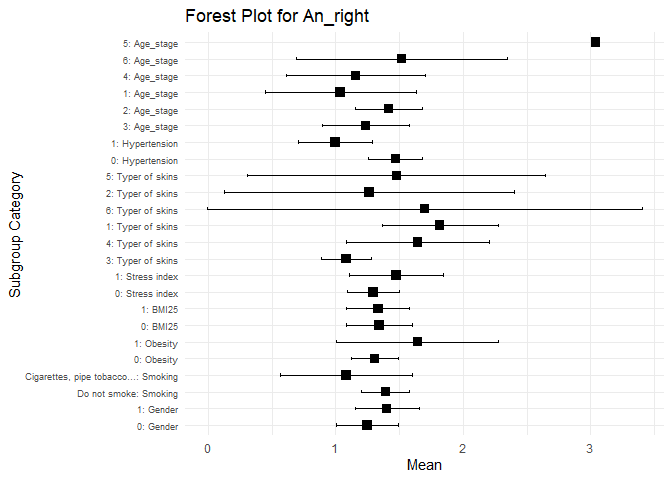

## Tạo bảng và Forest plot với biến Am_right

| Subgroup_Category | Subgroup | n_Am_right | Mean | CI_lower | CI_upper | P_Value |
| --- | --- | --- | --- | --- | --- | --- |
| Gender | 0 | 31 | 1.0274462 | 0.8013712 | 1.2535212 | 0.4448863 |
| Gender | 1 | 44 | 1.1082197 | 0.9214883 | 1.2949511 | 0.4448863 |
| Smoking | Do not smoke | 62 | 1.1246371 | 0.9718295 | 1.2774447 | 0.0903183 |
| Smoking | Cigarettes, pipe tobacco… | 13 | 0.8373077 | 0.4566053 | 1.2180101 | 0.0903183 |
| Obesity | 0 | 68 | 1.0744608 | 0.9214121 | 1.2275095 | 0.6293174 |
| Obesity | 1 | 7 | 1.0784524 | 0.7106217 | 1.4462830 | 0.6293174 |
| BMI25 | 0 | 42 | 1.0641667 | 0.8643431 | 1.2639903 | 0.6732895 |
| BMI25 | 1 | 33 | 1.0884091 | 0.8817820 | 1.2950362 | 0.6732895 |
| Stress index | 0 | 57 | 1.0297661 | 0.8728533 | 1.1866789 | 0.3031312 |
| Stress index | 1 | 18 | 1.2175463 | 0.8835430 | 1.5515496 | 0.3031312 |
| Typer of skins | 3 | 40 | 0.8827500 | 0.7100356 | 1.0554644 | NA |
| Typer of skins | 4 | 11 | 1.3680303 | 0.8848983 | 1.8511623 | NA |
| Typer of skins | 1 | 10 | 1.3569167 | 1.0510203 | 1.6628130 | NA |
| Typer of skins | 6 | 4 | 1.3350000 | -0.0687980 | 2.7387980 | NA |
| Typer of skins | 2 | 4 | 1.1625000 | 0.2426707 | 2.0823293 | NA |
| Typer of skins | 5 | 6 | 1.1158333 | 0.3478040 | 1.8838626 | NA |
| Hypertension | 0 | 54 | 1.1895370 | 1.0147376 | 1.3643365 | 0.0197697 |
| Hypertension | 1 | 21 | 0.7798810 | 0.5905095 | 0.9692524 | 0.0197697 |
| Age_stage | 3 | 13 | 0.9657692 | 0.6998203 | 1.2317182 | NA |
| Age_stage | 2 | 36 | 1.1440509 | 0.9367291 | 1.3513728 | NA |
| Age_stage | 1 | 7 | 0.8800000 | 0.2063582 | 1.5536418 | NA |
| Age_stage | 4 | 12 | 0.8937500 | 0.4939416 | 1.2935584 | NA |
| Age_stage | 6 | 6 | 1.2411111 | 0.6792881 | 1.8029341 | NA |
| Age_stage | 5 | 1 | 2.5400000 | NaN | NaN | NA |

Wilcox pairwise test cho các sub group có >2 level

```
## Group Gender does not have more than 2 unique levels. Skipping.
```

```
## Group Smoking does not have more than 2 unique levels. Skipping.
```

```
## Group Obesity does not have more than 2 unique levels. Skipping.
```

```
## Group BMI25 does not have more than 2 unique levels. Skipping.
```

```
## Group Stress index does not have more than 2 unique levels. Skipping.
```

```
## Group Hypertension does not have more than 2 unique levels. Skipping.
```

| Group | Group1 | Group2 | P_Value |
| --- | --- | --- | --- |
| Typer of skins | 3 | 4 | 0.0255262 |
| Typer of skins | 3 | 1 | 0.0042017 |
| Typer of skins | 3 | 6 | 0.2283135 |
| Typer of skins | 3 | 2 | 0.2528318 |
| Typer of skins | 3 | 5 | 0.3872430 |
| Typer of skins | 4 | 1 | 0.9725388 |
| Typer of skins | 4 | 6 | 0.9494505 |
| Typer of skins | 4 | 2 | 0.7531136 |
| Typer of skins | 4 | 5 | 0.5908209 |
| Typer of skins | 1 | 6 | 0.7332667 |
| Typer of skins | 1 | 2 | 0.3036963 |
| Typer of skins | 1 | 5 | 0.4922577 |
| Typer of skins | 6 | 2 | 0.8857143 |
| Typer of skins | 6 | 5 | 0.7619048 |
| Typer of skins | 2 | 5 | 0.9142857 |
| Age_stage | 3 | 2 | 0.5186160 |
| Age_stage | 3 | 1 | 0.2845377 |
| Age_stage | 3 | 4 | 0.5315525 |
| Age_stage | 3 | 6 | 0.3228660 |
| Age_stage | 3 | 5 | 0.1428571 |
| Age_stage | 2 | 1 | 0.1142621 |
| Age_stage | 2 | 4 | 0.2112500 |
| Age_stage | 2 | 6 | 0.6147525 |
| Age_stage | 2 | 5 | 0.1221912 |
| Age_stage | 1 | 4 | 1.0000000 |
| Age_stage | 1 | 6 | 0.1979256 |
| Age_stage | 1 | 5 | 0.2500000 |
| Age_stage | 4 | 6 | 0.2414634 |
| Age_stage | 4 | 5 | 0.1410316 |
| Age_stage | 6 | 5 | 0.2857143 |

Forest plot

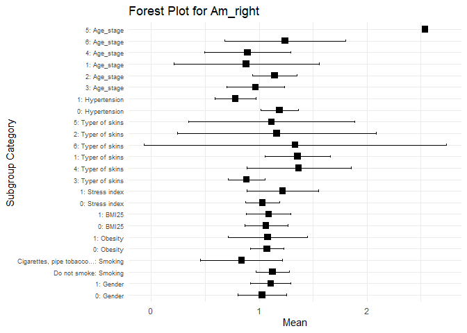

## Tạo bảng và Forest plot với biến Ar_right

| Subgroup_Category | Subgroup | n_Ar_right | Mean | CI_lower | CI_upper | P_Value |
| --- | --- | --- | --- | --- | --- | --- |
| Gender | 0 | 31 | 0.6700000 | 0.5481684 | 0.7918316 | 0.3746122 |
| Gender | 1 | 44 | 0.6885758 | 0.6028007 | 0.7743508 | 0.3746122 |
| Smoking | Do not smoke | 62 | 0.7030215 | 0.6280744 | 0.7779686 | 0.1744580 |
| Smoking | Cigarettes, pipe tobacco… | 13 | 0.5753846 | 0.3803088 | 0.7704605 | 0.1744580 |
| Obesity | 0 | 68 | 0.6794853 | 0.6035227 | 0.7554479 | 0.6292564 |
| Obesity | 1 | 7 | 0.6946190 | 0.5541682 | 0.8350698 | 0.6292564 |
| BMI25 | 0 | 42 | 0.6288095 | 0.5374663 | 0.7201528 | 0.1012533 |
| BMI25 | 1 | 33 | 0.7471919 | 0.6394074 | 0.8549765 | 0.1012533 |
| Stress index | 0 | 57 | 0.6569708 | 0.5724922 | 0.7414493 | 0.1208796 |
| Stress index | 1 | 18 | 0.7566667 | 0.6406080 | 0.8727253 | 0.1208796 |
| Typer of skins | 3 | 40 | 0.5547500 | 0.4764233 | 0.6330767 | NA |
| Typer of skins | 4 | 11 | 0.9190909 | 0.7279803 | 1.1102015 | NA |
| Typer of skins | 1 | 10 | 0.7297333 | 0.6387573 | 0.8207094 | NA |
| Typer of skins | 6 | 4 | 0.7625000 | 0.3218384 | 1.2031616 | NA |
| Typer of skins | 2 | 4 | 0.7125000 | 0.2836809 | 1.1413191 | NA |
| Typer of skins | 5 | 6 | 0.9283333 | 0.3903436 | 1.4663231 | NA |
| Hypertension | 0 | 54 | 0.7165432 | 0.6323133 | 0.8007731 | 0.1234873 |
| Hypertension | 1 | 21 | 0.5892381 | 0.4668300 | 0.7116462 | 0.1234873 |
| Age_stage | 3 | 13 | 0.6456923 | 0.5126235 | 0.7787611 | NA |
| Age_stage | 2 | 36 | 0.7098611 | 0.5991794 | 0.8205428 | NA |
| Age_stage | 1 | 7 | 0.5171429 | 0.3350700 | 0.6992157 | NA |
| Age_stage | 4 | 12 | 0.6375000 | 0.4091664 | 0.8658336 | NA |
| Age_stage | 6 | 6 | 0.7813889 | 0.5655733 | 0.9972044 | NA |
| Age_stage | 5 | 1 | 1.1600000 | NaN | NaN | NA |

Wilcox pairwise test cho các sub group có >2 level

```
## Group Gender does not have more than 2 unique levels. Skipping.
```

```
## Group Smoking does not have more than 2 unique levels. Skipping.
```

```
## Group Obesity does not have more than 2 unique levels. Skipping.
```

```
## Group BMI25 does not have more than 2 unique levels. Skipping.
```

```
## Group Stress index does not have more than 2 unique levels. Skipping.
```

```
## Group Hypertension does not have more than 2 unique levels. Skipping.
```

| Group | Group1 | Group2 | P_Value |
| --- | --- | --- | --- |
| Typer of skins | 3 | 4 | 0.0008583 |
| Typer of skins | 3 | 1 | 0.0124496 |
| Typer of skins | 3 | 6 | 0.1711707 |
| Typer of skins | 3 | 2 | 0.3168855 |
| Typer of skins | 3 | 5 | 0.0837442 |
| Typer of skins | 4 | 1 | 0.0977429 |
| Typer of skins | 4 | 6 | 0.3599061 |
| Typer of skins | 4 | 2 | 0.2144535 |
| Typer of skins | 4 | 5 | 0.9598971 |
| Typer of skins | 1 | 6 | 0.8318219 |
| Typer of skins | 1 | 2 | 0.7233819 |
| Typer of skins | 1 | 5 | 0.3561984 |
| Typer of skins | 6 | 2 | 0.7715034 |
| Typer of skins | 6 | 5 | 0.9142857 |
| Typer of skins | 2 | 5 | 0.6688699 |
| Age_stage | 3 | 2 | 0.7001983 |
| Age_stage | 3 | 1 | 0.2843564 |
| Age_stage | 3 | 4 | 1.0000000 |
| Age_stage | 3 | 6 | 0.2818075 |
| Age_stage | 3 | 5 | 0.1428571 |
| Age_stage | 2 | 1 | 0.1386347 |
| Age_stage | 2 | 4 | 0.5756799 |
| Age_stage | 2 | 6 | 0.3782452 |
| Age_stage | 2 | 5 | 0.2415669 |
| Age_stage | 1 | 4 | 0.4985854 |
| Age_stage | 1 | 6 | 0.0737482 |
| Age_stage | 1 | 5 | 0.1877813 |
| Age_stage | 4 | 6 | 0.4936436 |
| Age_stage | 4 | 5 | 0.1538462 |
| Age_stage | 6 | 5 | 0.2857143 |

Forest plot

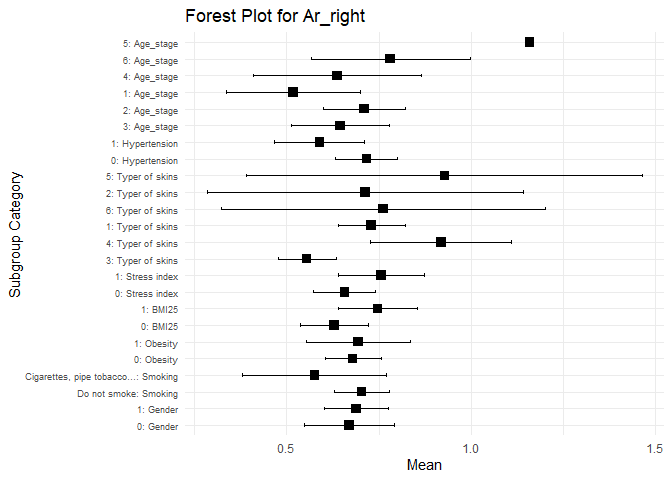

## Tạo bảng và Forest plot với biến Ac_right

| Subgroup_Category | Subgroup | n_Ac_right | Mean | CI_lower | CI_upper | P_Value |
| --- | --- | --- | --- | --- | --- | --- |
| Gender | 0 | 31 | 0.8793548 | 0.7351763 | 1.0235334 | 0.7549857 |
| Gender | 1 | 44 | 0.9059697 | 0.7691576 | 1.0427817 | 0.7549857 |
| Smoking | Do not smoke | 62 | 0.9203495 | 0.8220001 | 1.0186988 | 0.1287901 |
| Smoking | Cigarettes, pipe tobacco… | 13 | 0.7739231 | 0.4260776 | 1.1217685 | 0.1287901 |
| Obesity | 0 | 68 | 0.8892794 | 0.7844559 | 0.9941030 | 0.5722738 |
| Obesity | 1 | 7 | 0.9502381 | 0.6196996 | 1.2807766 | 0.5722738 |
| BMI25 | 0 | 42 | 0.8603016 | 0.7179524 | 1.0026508 | 0.3990308 |
| BMI25 | 1 | 33 | 0.9390909 | 0.8034112 | 1.0747706 | 0.3990308 |
| Stress index | 0 | 57 | 0.8660702 | 0.7452612 | 0.9868791 | 0.0963868 |
| Stress index | 1 | 18 | 0.9864815 | 0.8364173 | 1.1365456 | 0.0963868 |
| Typer of skins | 3 | 40 | 0.7703167 | 0.6379909 | 0.9026424 | NA |
| Typer of skins | 4 | 11 | 1.1536364 | 0.9028432 | 1.4044295 | NA |
| Typer of skins | 1 | 10 | 1.1060000 | 0.7489265 | 1.4630735 | NA |
| Typer of skins | 6 | 4 | 1.0375000 | 0.6544204 | 1.4205796 | NA |
| Typer of skins | 2 | 4 | 0.8275000 | 0.4839100 | 1.1710900 | NA |
| Typer of skins | 5 | 6 | 0.8500000 | 0.4264126 | 1.2735874 | NA |
| Hypertension | 0 | 54 | 0.9395864 | 0.8353739 | 1.0437989 | 0.0182547 |
| Hypertension | 1 | 21 | 0.7802381 | 0.5471220 | 1.0133542 | 0.0182547 |
| Age_stage | 3 | 13 | 0.8323077 | 0.7163865 | 0.9482288 | NA |
| Age_stage | 2 | 36 | 0.9475463 | 0.8093482 | 1.0857444 | NA |
| Age_stage | 1 | 7 | 0.6000000 | 0.4339565 | 0.7660435 | NA |
| Age_stage | 4 | 12 | 0.8659167 | 0.4728688 | 1.2589645 | NA |
| Age_stage | 6 | 6 | 1.0866667 | 0.4842707 | 1.6890626 | NA |
| Age_stage | 5 | 1 | 1.0800000 | NaN | NaN | NA |

Wilcox pairwise test cho các sub group có >2 level

```
## Group Gender does not have more than 2 unique levels. Skipping.
```

```
## Group Smoking does not have more than 2 unique levels. Skipping.
```

```
## Group Obesity does not have more than 2 unique levels. Skipping.
```

```
## Group BMI25 does not have more than 2 unique levels. Skipping.
```

```
## Group Stress index does not have more than 2 unique levels. Skipping.
```

```
## Group Hypertension does not have more than 2 unique levels. Skipping.
```

| Group | Group1 | Group2 | P_Value |
| --- | --- | --- | --- |
| Typer of skins | 3 | 4 | 0.0033681 |
| Typer of skins | 3 | 1 | 0.0403820 |
| Typer of skins | 3 | 6 | 0.0575790 |
| Typer of skins | 3 | 2 | 0.5135252 |
| Typer of skins | 3 | 5 | 0.6245500 |
| Typer of skins | 4 | 1 | 0.5492122 |
| Typer of skins | 4 | 6 | 0.6471162 |
| Typer of skins | 4 | 2 | 0.1696541 |
| Typer of skins | 4 | 5 | 0.1740509 |
| Typer of skins | 1 | 6 | 0.9450549 |
| Typer of skins | 1 | 2 | 0.4535465 |
| Typer of skins | 1 | 5 | 0.2544016 |
| Typer of skins | 6 | 2 | 0.3836303 |
| Typer of skins | 6 | 5 | 0.3314247 |
| Typer of skins | 2 | 5 | 0.7483812 |
| Age_stage | 3 | 2 | 0.5711818 |
| Age_stage | 3 | 1 | 0.0323255 |
| Age_stage | 3 | 4 | 0.5315525 |
| Age_stage | 3 | 6 | 0.2361962 |
| Age_stage | 3 | 5 | 0.1715029 |
| Age_stage | 2 | 1 | 0.0381197 |
| Age_stage | 2 | 4 | 0.3718168 |
| Age_stage | 2 | 6 | 0.6661260 |
| Age_stage | 2 | 5 | 0.6394163 |
| Age_stage | 1 | 4 | 0.3744378 |
| Age_stage | 1 | 6 | 0.0512821 |
| Age_stage | 1 | 5 | 0.2500000 |
| Age_stage | 4 | 6 | 0.2907778 |
| Age_stage | 4 | 5 | 0.6153846 |
| Age_stage | 6 | 5 | 0.8571429 |

Forest plot

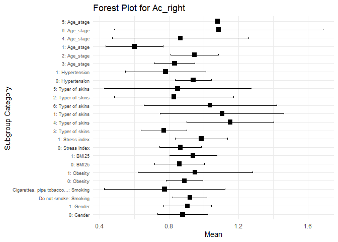

## Tạo bảng và Forest plot với biến F_Ae_right

| Subgroup_Category | Subgroup | n_F_Ae_right | Mean | CI_lower | CI_upper | P_Value |
| --- | --- | --- | --- | --- | --- | --- |
| Gender | 0 | 31 | 0.0146075 | 0.0132794 | 0.0159357 | 0.6888593 |
| Gender | 1 | 44 | 0.0148311 | 0.0137825 | 0.0158796 | 0.6888593 |
| Smoking | Do not smoke | 62 | 0.0146984 | 0.0137900 | 0.0156068 | 0.8547887 |
| Smoking | Cigarettes, pipe tobacco… | 13 | 0.0149308 | 0.0129840 | 0.0168776 | 0.8547887 |
| Obesity | 0 | 68 | 0.0145799 | 0.0137231 | 0.0154367 | 0.2373761 |
| Obesity | 1 | 7 | 0.0162810 | 0.0136692 | 0.0188927 | 0.2373761 |
| BMI25 | 0 | 42 | 0.0143635 | 0.0133531 | 0.0153739 | 0.4176360 |
| BMI25 | 1 | 33 | 0.0152162 | 0.0138701 | 0.0165622 | 0.4176360 |
| Stress index | 0 | 57 | 0.0148433 | 0.0139029 | 0.0157837 | 0.6177072 |
| Stress index | 1 | 18 | 0.0144074 | 0.0127033 | 0.0161115 | 0.6177072 |
| Typer of skins | 3 | 40 | 0.0141608 | 0.0130384 | 0.0152833 | NA |
| Typer of skins | 4 | 11 | 0.0148939 | 0.0127546 | 0.0170332 | NA |
| Typer of skins | 1 | 10 | 0.0178133 | 0.0158976 | 0.0197291 | NA |
| Typer of skins | 6 | 4 | 0.0122500 | 0.0080652 | 0.0164348 | NA |
| Typer of skins | 2 | 4 | 0.0155000 | 0.0084434 | 0.0225566 | NA |
| Typer of skins | 5 | 6 | 0.0143333 | 0.0112439 | 0.0174228 | NA |
| Hypertension | 0 | 54 | 0.0147889 | 0.0138050 | 0.0157728 | 0.9102279 |
| Hypertension | 1 | 21 | 0.0146095 | 0.0131121 | 0.0161070 | 0.9102279 |
| Age_stage | 3 | 13 | 0.0150615 | 0.0130265 | 0.0170966 | NA |
| Age_stage | 2 | 36 | 0.0148657 | 0.0136393 | 0.0160921 | NA |
| Age_stage | 1 | 7 | 0.0117143 | 0.0099665 | 0.0134621 | NA |
| Age_stage | 4 | 12 | 0.0148417 | 0.0125969 | 0.0170865 | NA |
| Age_stage | 6 | 6 | 0.0170556 | 0.0139001 | 0.0202110 | NA |
| Age_stage | 5 | 1 | 0.0120000 | NaN | NaN | NA |

Wilcox pairwise test cho các sub group có >2 level

```
## Group Gender does not have more than 2 unique levels. Skipping.
```

```
## Group Smoking does not have more than 2 unique levels. Skipping.
```

```
## Group Obesity does not have more than 2 unique levels. Skipping.
```

```
## Group BMI25 does not have more than 2 unique levels. Skipping.
```

```
## Group Stress index does not have more than 2 unique levels. Skipping.
```

```
## Group Hypertension does not have more than 2 unique levels. Skipping.
```

| Group | Group1 | Group2 | P_Value |
| --- | --- | --- | --- |
| Typer of skins | 3 | 4 | 0.3996574 |
| Typer of skins | 3 | 1 | 0.0079016 |
| Typer of skins | 3 | 6 | 0.2921094 |
| Typer of skins | 3 | 2 | 0.5494980 |
| Typer of skins | 3 | 5 | 0.8049418 |
| Typer of skins | 4 | 1 | 0.0600853 |
| Typer of skins | 4 | 6 | 0.1017628 |
| Typer of skins | 4 | 2 | 0.7936422 |
| Typer of skins | 4 | 5 | 0.7621749 |
| Typer of skins | 1 | 6 | 0.0182983 |
| Typer of skins | 1 | 2 | 0.3471492 |
| Typer of skins | 1 | 5 | 0.0432253 |
| Typer of skins | 6 | 2 | 0.3836303 |
| Typer of skins | 6 | 5 | 0.2820039 |
| Typer of skins | 2 | 5 | 0.7619048 |
| Age_stage | 3 | 2 | 0.9455454 |
| Age_stage | 3 | 1 | 0.0409658 |
| Age_stage | 3 | 4 | 1.0000000 |
| Age_stage | 3 | 6 | 0.2347527 |
| Age_stage | 3 | 5 | 0.5305916 |
| Age_stage | 2 | 1 | 0.0298747 |
| Age_stage | 2 | 4 | 0.8950714 |
| Age_stage | 2 | 6 | 0.2185444 |
| Age_stage | 2 | 5 | 0.4224610 |
| Age_stage | 1 | 4 | 0.0520233 |
| Age_stage | 1 | 6 | 0.0176204 |
| Age_stage | 1 | 5 | 1.0000000 |
| Age_stage | 4 | 6 | 0.3208668 |
| Age_stage | 4 | 5 | 0.4906292 |
| Age_stage | 6 | 5 | 0.5714286 |

Forest plot

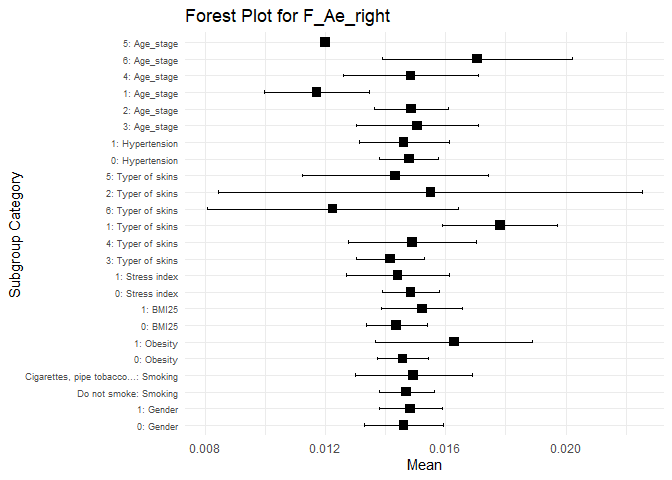

## Tạo bảng và Forest plot với biến F_An_right

| Subgroup_Category | Subgroup | n_F_An_right | Mean | CI_lower | CI_upper | P_Value |
| --- | --- | --- | --- | --- | --- | --- |
| Gender | 0 | 31 | 0.0344140 | 0.0307170 | 0.0381109 | 0.1365770 |
| Gender | 1 | 44 | 0.0313795 | 0.0280826 | 0.0346764 | 0.1365770 |
| Smoking | Do not smoke | 62 | 0.0330618 | 0.0303646 | 0.0357591 | 0.3653913 |
| Smoking | Cigarettes, pipe tobacco… | 13 | 0.0305923 | 0.0242431 | 0.0369415 | 0.3653913 |
| Obesity | 0 | 68 | 0.0327725 | 0.0301690 | 0.0353761 | 0.8408011 |
| Obesity | 1 | 7 | 0.0312857 | 0.0227932 | 0.0397783 | 0.8408011 |
| BMI25 | 0 | 42 | 0.0324294 | 0.0290607 | 0.0357980 | 0.7400823 |
| BMI25 | 1 | 33 | 0.0328939 | 0.0291981 | 0.0365897 | 0.7400823 |
| Stress index | 0 | 57 | 0.0320766 | 0.0292912 | 0.0348621 | 0.3805532 |
| Stress index | 1 | 18 | 0.0343981 | 0.0289689 | 0.0398274 | 0.3805532 |
| Typer of skins | 3 | 40 | 0.0321467 | 0.0286298 | 0.0356635 | NA |
| Typer of skins | 4 | 11 | 0.0356970 | 0.0280876 | 0.0433063 | NA |
| Typer of skins | 1 | 10 | 0.0304000 | 0.0255900 | 0.0352100 | NA |
| Typer of skins | 6 | 4 | 0.0307500 | 0.0231326 | 0.0383674 | NA |
| Typer of skins | 2 | 4 | 0.0385000 | 0.0095211 | 0.0674789 | NA |
| Typer of skins | 5 | 6 | 0.0313333 | 0.0210796 | 0.0415871 | NA |
| Hypertension | 0 | 54 | 0.0324543 | 0.0298192 | 0.0350895 | 0.6962268 |
| Hypertension | 1 | 21 | 0.0330952 | 0.0272258 | 0.0389647 | 0.6962268 |
| Age_stage | 3 | 13 | 0.0303846 | 0.0238120 | 0.0369572 | NA |
| Age_stage | 2 | 36 | 0.0336065 | 0.0299658 | 0.0372471 | NA |
| Age_stage | 1 | 7 | 0.0405000 | 0.0313952 | 0.0496048 | NA |
| Age_stage | 4 | 12 | 0.0266417 | 0.0225781 | 0.0307053 | NA |
| Age_stage | 6 | 6 | 0.0337500 | 0.0206604 | 0.0468396 | NA |
| Age_stage | 5 | 1 | 0.0370000 | NaN | NaN | NA |

Wilcox pairwise test cho các sub group có >2 level

```
## Group Gender does not have more than 2 unique levels. Skipping.
```

```
## Group Smoking does not have more than 2 unique levels. Skipping.
```

```
## Group Obesity does not have more than 2 unique levels. Skipping.
```

```
## Group BMI25 does not have more than 2 unique levels. Skipping.
```

```
## Group Stress index does not have more than 2 unique levels. Skipping.
```

```
## Group Hypertension does not have more than 2 unique levels. Skipping.
```

| Group | Group1 | Group2 | P_Value |
| --- | --- | --- | --- |
| Typer of skins | 3 | 4 | 0.2842174 |
| Typer of skins | 3 | 1 | 0.9514243 |
| Typer of skins | 3 | 6 | 0.9181712 |
| Typer of skins | 3 | 2 | 0.4594594 |
| Typer of skins | 3 | 5 | 1.0000000 |
| Typer of skins | 4 | 1 | 0.3781182 |
| Typer of skins | 4 | 6 | 0.5565072 |
| Typer of skins | 4 | 2 | 0.7934612 |
| Typer of skins | 4 | 5 | 0.4504267 |
| Typer of skins | 1 | 6 | 0.7758539 |
| Typer of skins | 1 | 2 | 0.8312718 |
| Typer of skins | 1 | 5 | 0.9567180 |
| Typer of skins | 6 | 2 | 1.0000000 |
| Typer of skins | 6 | 5 | 1.0000000 |
| Typer of skins | 2 | 5 | 0.6095238 |
| Age_stage | 3 | 2 | 0.3340986 |
| Age_stage | 3 | 1 | 0.0516734 |
| Age_stage | 3 | 4 | 0.4927093 |
| Age_stage | 3 | 6 | 0.2904585 |
| Age_stage | 3 | 5 | 0.6178585 |
| Age_stage | 2 | 1 | 0.1062240 |
| Age_stage | 2 | 4 | 0.0528814 |
| Age_stage | 2 | 6 | 0.9569022 |
| Age_stage | 2 | 5 | 0.6054611 |
| Age_stage | 1 | 4 | 0.0051679 |
| Age_stage | 1 | 6 | 0.1150803 |
| Age_stage | 1 | 5 | 1.0000000 |
| Age_stage | 4 | 6 | 0.1199401 |
| Age_stage | 4 | 5 | 0.2258870 |
| Age_stage | 6 | 5 | 0.4491772 |

Forest plot

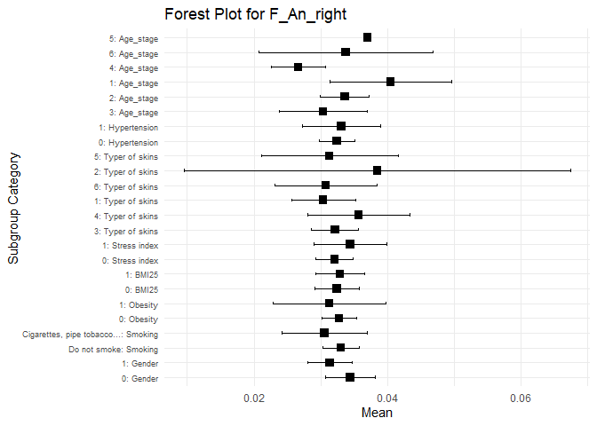

## Tạo bảng và Forest plot với biến F_Am_right

| Subgroup_Category | Subgroup | n_F_Am_right | Mean | CI_lower | CI_upper | P_Value |
| --- | --- | --- | --- | --- | --- | --- |
| Gender | 0 | 31 | 0.0841452 | 0.0716867 | 0.0966036 | 0.8452175 |
| Gender | 1 | 44 | 0.0879409 | 0.0754352 | 0.1004466 | 0.8452175 |
| Smoking | Do not smoke | 62 | 0.0822774 | 0.0740625 | 0.0904923 | 0.2092199 |
| Smoking | Cigarettes, pipe tobacco… | 13 | 0.1059000 | 0.0719856 | 0.1398144 | 0.2092199 |
| Obesity | 0 | 68 | 0.0874588 | 0.0779159 | 0.0970017 | 0.6136357 |
| Obesity | 1 | 7 | 0.0758143 | 0.0564762 | 0.0951524 | 0.6136357 |
| BMI25 | 0 | 42 | 0.0873738 | 0.0748923 | 0.0998553 | 0.8887614 |
| BMI25 | 1 | 33 | 0.0850970 | 0.0722887 | 0.0979052 | 0.8887614 |
| Stress index | 0 | 57 | 0.0867292 | 0.0762248 | 0.0972336 | 0.7688536 |
| Stress index | 1 | 18 | 0.0852407 | 0.0682584 | 0.1022230 | 0.7688536 |
| Typer of skins | 3 | 40 | 0.0869800 | 0.0750065 | 0.0989535 | NA |
| Typer of skins | 4 | 11 | 0.0802576 | 0.0637040 | 0.0968112 | NA |
| Typer of skins | 1 | 10 | 0.0830367 | 0.0533517 | 0.1127216 | NA |
| Typer of skins | 6 | 4 | 0.0970000 | -0.0082375 | 0.2022375 | NA |
| Typer of skins | 2 | 4 | 0.0780000 | 0.0270312 | 0.1289688 | NA |
| Typer of skins | 5 | 6 | 0.0975833 | 0.0437304 | 0.1514363 | NA |
| Hypertension | 0 | 54 | 0.0820500 | 0.0734914 | 0.0906086 | 0.3413031 |
| Hypertension | 1 | 21 | 0.0974857 | 0.0742950 | 0.1206764 | 0.3413031 |
| Age_stage | 3 | 13 | 0.0857462 | 0.0613356 | 0.1101567 | NA |
| Age_stage | 2 | 36 | 0.0879676 | 0.0744777 | 0.1014575 | NA |
| Age_stage | 1 | 7 | 0.0813571 | 0.0623196 | 0.1003947 | NA |
| Age_stage | 4 | 12 | 0.0840583 | 0.0606291 | 0.1074876 | NA |
| Age_stage | 6 | 6 | 0.0928611 | 0.0379787 | 0.1477435 | NA |
| Age_stage | 5 | 1 | 0.0610000 | NaN | NaN | NA |

Wilcox pairwise test cho các sub group có >2 level

```
## Group Gender does not have more than 2 unique levels. Skipping.
```

```
## Group Smoking does not have more than 2 unique levels. Skipping.
```

```
## Group Obesity does not have more than 2 unique levels. Skipping.
```

```
## Group BMI25 does not have more than 2 unique levels. Skipping.
```

```
## Group Stress index does not have more than 2 unique levels. Skipping.
```

```
## Group Hypertension does not have more than 2 unique levels. Skipping.
```

| Group | Group1 | Group2 | P_Value |
| --- | --- | --- | --- |
| Typer of skins | 3 | 4 | 0.6122393 |
| Typer of skins | 3 | 1 | 0.4347550 |
| Typer of skins | 3 | 6 | 0.4837757 |
| Typer of skins | 3 | 2 | 0.3031705 |
| Typer of skins | 3 | 5 | 0.7552560 |
| Typer of skins | 4 | 1 | 0.7767078 |
| Typer of skins | 4 | 6 | 0.7918108 |
| Typer of skins | 4 | 2 | 0.4670924 |
| Typer of skins | 4 | 5 | 0.8401117 |
| Typer of skins | 1 | 6 | 0.8860343 |
| Typer of skins | 1 | 2 | 0.5180082 |
| Typer of skins | 1 | 5 | 0.5487374 |
| Typer of skins | 6 | 2 | 0.8777823 |
| Typer of skins | 6 | 5 | 0.6650055 |
| Typer of skins | 2 | 5 | 0.4499999 |
| Age_stage | 3 | 2 | 0.8549333 |
| Age_stage | 3 | 1 | 0.7479448 |
| Age_stage | 3 | 4 | 0.5642970 |
| Age_stage | 3 | 6 | 0.8594070 |
| Age_stage | 3 | 5 | 0.3096289 |
| Age_stage | 2 | 1 | 0.8944007 |
| Age_stage | 2 | 4 | 0.7736700 |
| Age_stage | 2 | 6 | 0.8277649 |
| Age_stage | 2 | 5 | 0.2012142 |
| Age_stage | 1 | 4 | 0.9322602 |
| Age_stage | 1 | 6 | 0.8856201 |
| Age_stage | 1 | 5 | 0.3710934 |
| Age_stage | 4 | 6 | 0.8878135 |
| Age_stage | 4 | 5 | 0.2252400 |
| Age_stage | 6 | 5 | 0.3129507 |

Forest plot

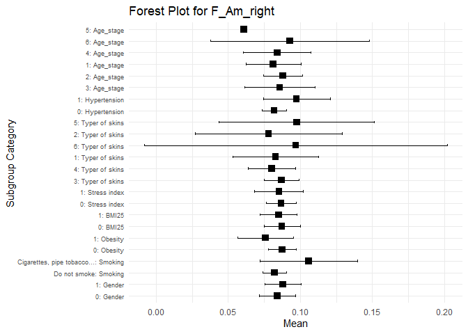

## Tạo bảng và Forest plot với biến F_Ar_right

| Subgroup_Category | Subgroup | n_F_Ar_right | Mean | CI_lower | CI_upper | P_Value |
| --- | --- | --- | --- | --- | --- | --- |
| Gender | 0 | 31 | 0.3290511 | 0.2758115 | 0.3822907 | 0.9565113 |
| Gender | 1 | 44 | 0.3167152 | 0.2761227 | 0.3573076 | 0.9565113 |
| Smoking | Do not smoke | 62 | 0.3324137 | 0.2961701 | 0.3686573 | 0.2333425 |
| Smoking | Cigarettes, pipe tobacco… | 13 | 0.2712615 | 0.2111733 | 0.3313498 | 0.2333425 |
| Obesity | 0 | 68 | 0.3150034 | 0.2812005 | 0.3488064 | 0.0353174 |
| Obesity | 1 | 7 | 0.3879738 | 0.2948430 | 0.4811047 | 0.0353174 |
| BMI25 | 0 | 42 | 0.3054897 | 0.2626171 | 0.3483622 | 0.0501913 |
| BMI25 | 1 | 33 | 0.3425904 | 0.2940437 | 0.3911371 | 0.0501913 |
| Stress index | 0 | 57 | 0.3131749 | 0.2774903 | 0.3488594 | 0.5377722 |
| Stress index | 1 | 18 | 0.3491713 | 0.2757365 | 0.4226061 | 0.5377722 |
| Typer of skins | 3 | 40 | 0.3168558 | 0.2723223 | 0.3613894 | NA |
| Typer of skins | 4 | 11 | 0.3073939 | 0.2122064 | 0.4025814 | NA |
| Typer of skins | 1 | 10 | 0.3134483 | 0.2304038 | 0.3964929 | NA |
| Typer of skins | 6 | 4 | 0.4375000 | 0.1789781 | 0.6960219 | NA |
| Typer of skins | 2 | 4 | 0.3390000 | 0.0610077 | 0.6169923 | NA |
| Typer of skins | 5 | 6 | 0.3066667 | 0.1641200 | 0.4492134 | NA |
| Hypertension | 0 | 54 | 0.3127111 | 0.2763902 | 0.3490320 | 0.3891159 |
| Hypertension | 1 | 21 | 0.3452214 | 0.2771825 | 0.4132604 | 0.3891159 |
| Age_stage | 3 | 13 | 0.3411462 | 0.2671845 | 0.4151078 | NA |
| Age_stage | 2 | 36 | 0.3110671 | 0.2617607 | 0.3603736 | NA |
| Age_stage | 1 | 7 | 0.3465714 | 0.1976781 | 0.4954648 | NA |
| Age_stage | 4 | 12 | 0.2982000 | 0.2149278 | 0.3814722 | NA |
| Age_stage | 6 | 6 | 0.3820556 | 0.2504373 | 0.5136738 | NA |
| Age_stage | 5 | 1 | 0.2060000 | NaN | NaN | NA |

Wilcox pairwise test cho các sub group có >2 level

```
## Group Gender does not have more than 2 unique levels. Skipping.
```

```
## Group Smoking does not have more than 2 unique levels. Skipping.
```

```
## Group Obesity does not have more than 2 unique levels. Skipping.
```

```
## Group BMI25 does not have more than 2 unique levels. Skipping.
```

```
## Group Stress index does not have more than 2 unique levels. Skipping.
```

```
## Group Hypertension does not have more than 2 unique levels. Skipping.
```

| Group | Group1 | Group2 | P_Value |
| --- | --- | --- | --- |
| Typer of skins | 3 | 4 | 0.5445120 |
| Typer of skins | 3 | 1 | 0.9313640 |
| Typer of skins | 3 | 6 | 0.2995550 |
| Typer of skins | 3 | 2 | 0.9006526 |
| Typer of skins | 3 | 5 | 0.8172285 |
| Typer of skins | 4 | 1 | 0.8295528 |
| Typer of skins | 4 | 6 | 0.2870487 |
| Typer of skins | 4 | 2 | 1.0000000 |
| Typer of skins | 4 | 5 | 0.4176457 |
| Typer of skins | 1 | 6 | 0.2526186 |
| Typer of skins | 1 | 2 | 0.9423489 |
| Typer of skins | 1 | 5 | 0.9565579 |
| Typer of skins | 6 | 2 | 0.5516159 |
| Typer of skins | 6 | 5 | 0.5186050 |
| Typer of skins | 2 | 5 | 0.8291180 |
| Age_stage | 3 | 2 | 0.1850678 |
| Age_stage | 3 | 1 | 0.8732204 |
| Age_stage | 3 | 4 | 0.2398598 |
| Age_stage | 3 | 6 | 0.5097411 |
| Age_stage | 3 | 5 | 0.2123172 |
| Age_stage | 2 | 1 | 0.4673699 |
| Age_stage | 2 | 4 | 0.8647467 |
| Age_stage | 2 | 6 | 0.1334142 |
| Age_stage | 2 | 5 | 0.2875047 |
| Age_stage | 1 | 4 | 0.4673999 |
| Age_stage | 1 | 6 | 0.6669421 |
| Age_stage | 1 | 5 | 0.3680828 |
| Age_stage | 4 | 6 | 0.1453309 |
| Age_stage | 4 | 5 | 0.2783474 |
| Age_stage | 6 | 5 | 0.2857143 |

Forest plot

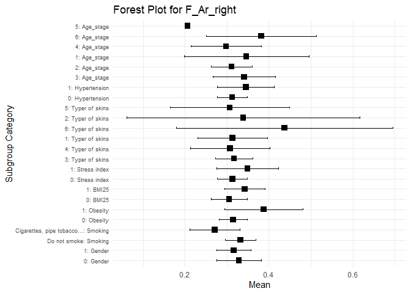

## Tạo bảng và Forest plot với biến F_Ac_right

| Subgroup_Category | Subgroup | n_F_Ac_right | Mean | CI_lower | CI_upper | P_Value |
| --- | --- | --- | --- | --- | --- | --- |
| Gender | 0 | 31 | 1.135505 | 1.0633014 | 1.207709 | 0.7544507 |
| Gender | 1 | 44 | 1.148052 | 1.0924587 | 1.203646 | 0.7544507 |
| Smoking | Do not smoke | 62 | 1.126638 | 1.0796351 | 1.173641 | 0.2676827 |
| Smoking | Cigarettes, pipe tobacco… | 13 | 1.220262 | 1.1073123 | 1.333211 | 0.2676827 |
| Obesity | 0 | 68 | 1.137935 | 1.0925605 | 1.183309 | 0.4596487 |
| Obesity | 1 | 7 | 1.190771 | 1.0093105 | 1.372232 | 0.4596487 |
| BMI25 | 0 | 42 | 1.145271 | 1.0782118 | 1.212331 | 0.7685786 |
| BMI25 | 1 | 33 | 1.139805 | 1.0872164 | 1.192394 | 0.7685786 |
| Stress index | 0 | 57 | 1.151833 | 1.1021548 | 1.201511 | 0.5630896 |
| Stress index | 1 | 18 | 1.114472 | 1.0194281 | 1.209516 | 0.5630896 |
| Typer of skins | 3 | 40 | 1.133847 | 1.0674469 | 1.200248 | NA |
| Typer of skins | 4 | 11 | 1.124227 | 1.0407410 | 1.207714 | NA |
| Typer of skins | 1 | 10 | 1.133507 | 1.0045380 | 1.262475 | NA |
| Typer of skins | 6 | 4 | 1.171500 | 0.9243306 | 1.418669 | NA |
| Typer of skins | 2 | 4 | 1.129000 | 0.9098383 | 1.348162 | NA |
| Typer of skins | 5 | 6 | 1.242917 | 0.9974191 | 1.488414 | NA |
| Hypertension | 0 | 54 | 1.133547 | 1.0863346 | 1.180761 | 0.3500637 |
| Hypertension | 1 | 21 | 1.166829 | 1.0650144 | 1.268643 | 0.3500637 |
| Age_stage | 3 | 13 | 1.190531 | 1.1145505 | 1.266511 | NA |
| Age_stage | 2 | 36 | 1.115000 | 1.0458040 | 1.184196 | NA |
| Age_stage | 1 | 7 | 1.255000 | 1.0633610 | 1.446639 | NA |
| Age_stage | 4 | 12 | 1.146367 | 1.0279713 | 1.264762 | NA |
| Age_stage | 6 | 6 | 1.060611 | 0.8972144 | 1.224008 | NA |
| Age_stage | 5 | 1 | 1.193000 | NaN | NaN | NA |

Wilcox pairwise test cho các sub group có >2 level

```
## Group Gender does not have more than 2 unique levels. Skipping.
```

```
## Group Smoking does not have more than 2 unique levels. Skipping.
```

```
## Group Obesity does not have more than 2 unique levels. Skipping.
```

```
## Group BMI25 does not have more than 2 unique levels. Skipping.
```

```
## Group Stress index does not have more than 2 unique levels. Skipping.
```

```
## Group Hypertension does not have more than 2 unique levels. Skipping.
```

| Group | Group1 | Group2 | P_Value |
| --- | --- | --- | --- |
| Typer of skins | 3 | 4 | 0.6540654 |
| Typer of skins | 3 | 1 | 0.7519194 |
| Typer of skins | 3 | 6 | 0.9021486 |
| Typer of skins | 3 | 2 | 0.7897738 |
| Typer of skins | 3 | 5 | 0.1850433 |
| Typer of skins | 4 | 1 | 0.9718766 |
| Typer of skins | 4 | 6 | 0.6939982 |
| Typer of skins | 4 | 2 | 1.0000000 |
| Typer of skins | 4 | 5 | 0.1745801 |
| Typer of skins | 1 | 6 | 0.6696601 |
| Typer of skins | 1 | 2 | 0.7768193 |
| Typer of skins | 1 | 5 | 0.3551334 |
| Typer of skins | 6 | 2 | 1.0000000 |
| Typer of skins | 6 | 5 | 0.5211659 |
| Typer of skins | 2 | 5 | 0.3523810 |
| Age_stage | 3 | 2 | 0.3173940 |
| Age_stage | 3 | 1 | 0.4503712 |
| Age_stage | 3 | 4 | 0.3085433 |
| Age_stage | 3 | 6 | 0.0786199 |
| Age_stage | 3 | 5 | 1.0000000 |
| Age_stage | 2 | 1 | 0.1169572 |
| Age_stage | 2 | 4 | 0.9524239 |
| Age_stage | 2 | 6 | 0.4276686 |
| Age_stage | 2 | 5 | 0.8509133 |
| Age_stage | 1 | 4 | 0.2691513 |
| Age_stage | 1 | 6 | 0.0976071 |
| Age_stage | 1 | 5 | 1.0000000 |
| Age_stage | 4 | 6 | 0.2998834 |
| Age_stage | 4 | 5 | 0.6796200 |
| Age_stage | 6 | 5 | 0.5714286 |

Forest plot

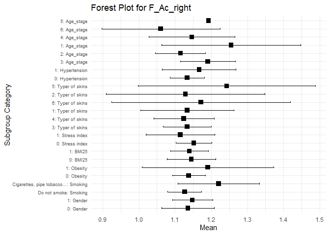